# Project_Fish

Akshita

2024-04-28

```r
library(readr)
fish <- read.csv("C:/Users/HP/Desktop/USA/Spring'24/Multivariate/Datasets/Fish_dataset.csv")
str(fish)
```

```
## 'data.frame':    158 obs. of  7 variables:
##  $ Species: chr  "Bream" "Bream" "Bream" "Bream" ...
##  $ Weight : num  242 290 340 363 430 450 500 390 450 500 ...
##  $ Length1: num  23.2 24 23.9 26.3 26.5 26.8 26.8 27.6 27.6 28.5 ...
##  $ Length2: num  25.4 26.3 26.5 29 29 29.7 29.7 30 30 30.7 ...
##  $ Length3: num  30 31.2 31.1 33.5 34 34.7 34.5 35 35.1 36.2 ...
##  $ Height : num  11.5 12.5 12.4 12.7 12.4 ...
##  $ Width  : num  4.02 4.31 4.7 4.46 5.13 ...
```

```r
# Check for null values
null_values <- colSums(is.na(fish))

# Print the count of null values for each column
print(null_values)
```

```
## Species  Weight Length1 Length2 Length3  Height   Width
##       0       0       0       0       0       0       0
```

```r
# Print columns with null values, if any
cols_with_null <- names(null_values[null_values > 0])
if (length(cols_with_null) > 0) {
  cat("Columns with null values:", paste(cols_with_null, collapse = ", "))
} else {
  cat("No null values found in the dataset.")
}
```

```
## No null values found in the dataset.
```

```r
fish_cleaned <- fish[,-1]
str(fish_cleaned)
```

```
## 'data.frame':    158 obs. of  6 variables:
##  $ Weight : num  242 290 340 363 430 450 500 390 450 500 ...
##  $ Length1: num  23.2 24 23.9 26.3 26.5 26.8 26.8 27.6 27.6 28.5 ...
##  $ Length2: num  25.4 26.3 26.5 29 29 29.7 29.7 30 30 30.7 ...
##  $ Length3: num  30 31.2 31.1 33.5 34 34.7 34.5 35 35.1 36.2 ...
##  $ Height : num  11.5 12.5 12.4 12.7 12.4 ...
##  $ Width  : num  4.02 4.31 4.7 4.46 5.13 ...
```

This dataset is a record of 7 common different fish species in fish market sales. With this dataset, a predictive model can be performed using machine friendly data and estimate the weight of fish can be predicted.

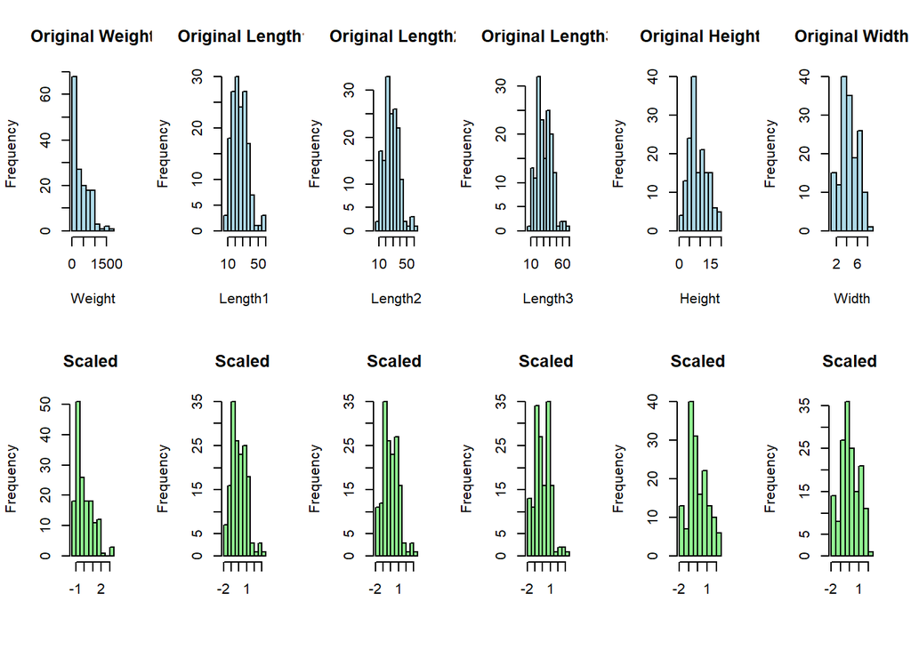

```r
# Scale the variables
scaled_fish_data <- scale(fish_cleaned)

#comparing original and scaled values
# Plot histograms for original data
par(mfrow=c(2, ncol(fish_cleaned)))  # Set up plotting layout

for (i in 1:(ncol(fish_cleaned))) {  # Exclude the last column (Feelings_Category)
  hist(fish_cleaned[, i], main = paste("Original", names(fish_cleaned)[i]), xlab = names(fish_cleaned)[i], col = "lightblue")
}

# Plot histograms for scaled data
for (i in 1:(ncol(scaled_fish_data))) {
  hist(scaled_fish_data[, i], main = paste("Scaled", names(scaled_fish_data)[i]), xlab = names(scaled_fish_data)[i], col = "lightgreen")
}
```

EDA

```r
# Install and load the psych package
library(psych)
# Perform PCA
pca_result <- prcomp(scaled_fish_data)
print(pca_result)
```

```
## Standard deviations (1, .., p=6):
## [1] 2.29530871 0.71538652 0.34733807 0.31189605 0.03974234 0.01666500
##
## Rotation (n x k) = (6 x 6):
##               PC1         PC2        PC3         PC4         PC5          PC6
## Weight  0.4174145 -0.03934572  0.2195906  0.88064340  0.02130717  0.003194724
## Length1 0.4215573 -0.33510472 -0.1659288 -0.15960339 -0.47183600 -0.659059494
## Length2 0.4234438 -0.30863947 -0.1721405 -0.16629765 -0.33015927  0.747759733
## Length3 0.4276972 -0.19677220 -0.3322752 -0.14772533  0.79986934 -0.079594435
## Height  0.3425075  0.84288953 -0.3890823 -0.02421089 -0.14226749 -0.003821636
## Width   0.4105041  0.20424583  0.7955020 -0.38591465  0.08877305 -0.011656740
```

```r
summary(pca_result)
```

```
## Importance of components:
##                           PC1    PC2     PC3     PC4     PC5     PC6
## Standard deviation     2.2953 0.7154 0.34734 0.31190 0.03974 0.01666
## Proportion of Variance 0.8781 0.0853 0.02011 0.01621 0.00026 0.00005
## Cumulative Proportion  0.8781 0.9634 0.98348 0.99969 0.99995 1.00000
```

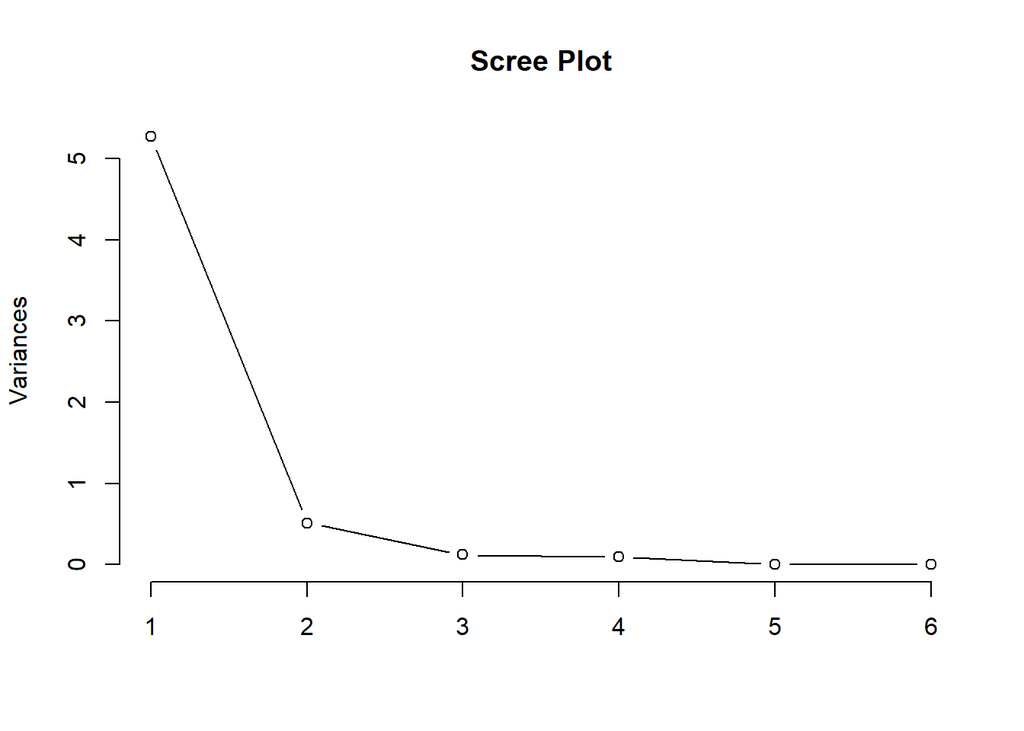

```r
# Scree plot
plot(pca_result, type = "l", main = "Scree Plot")
```

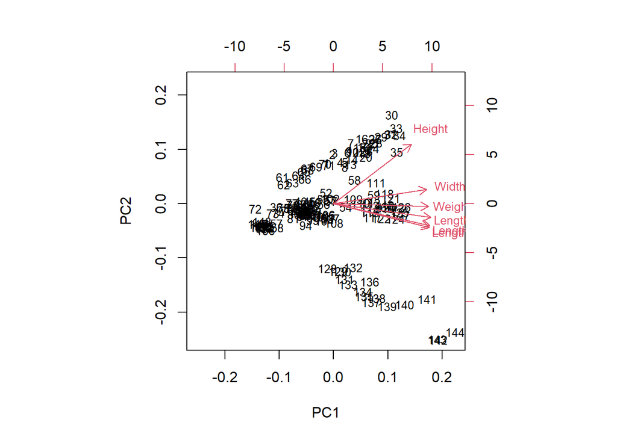

```r
# Biplot
biplot(pca_result, cex = 0.8)
```

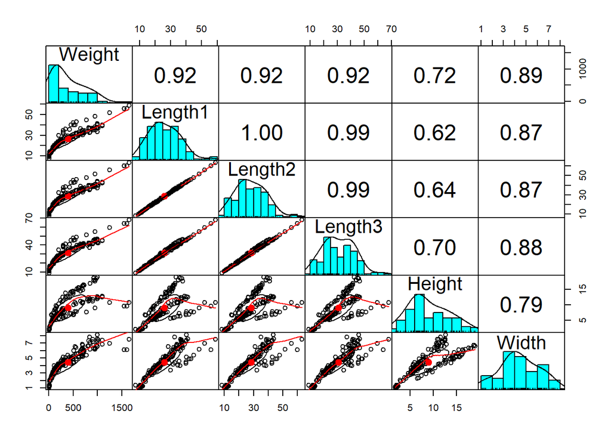

```r
# Correlation
pairs.panels(fish_cleaned,
              gap = 0,
              bg = c("red", "blue")[fish$Species],
              pch=21)
```

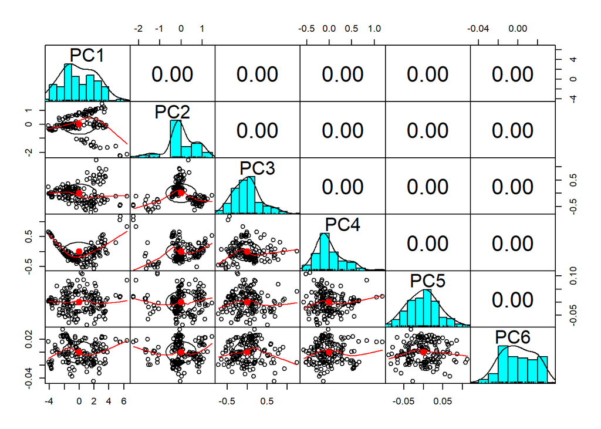

```r
pairs.panels(pca_result$x,
              gap=0,
              bg = c("red", "blue")[fish$Species],
              pch=21)
```

1. Variance:

The first principal component (PC1) explains approximately 87.81% of the total variance in the data, indicating that a large amount of information can be summarized by this component alone.

PC2 explains about 8.53% of the variance, and together with PC1, they explain around 96.34% of the total variance. This suggests that these two components capture the majority of the variability in the dataset.

2. Component Loadings:

The rotation matrix (the loadings) shows the relationships between the original variables (fish characteristics) and the principal components. Higher absolute values in the loading matrix indicate stronger correlations between variables and components.

For example, Weight, Length1, Length2, Length3, and Width have relatively high loadings on PC1, while Height has a moderate loading. This suggests that PC1 is primarily influenced by these variables, perhaps representing overall size or growth of the fish.

3. Interpretation:

The first principal component seems to represent overall size or growth of the fish, as it is strongly correlated with variables like Weight and various length measurements.

```r
# Perform Factor Analysis
fa_result_fish <- fa(scaled_fish_data, nfactors = 3, rotate = "varimax")
print(fa_result_fish)
```

```
## Factor Analysis using method =  minres
## Call: fa(r = scaled_fish_data, nfactors = 3, rotate = "varimax")
## Standardized loadings (pattern matrix) based upon correlation matrix
##          MR1  MR2  MR3   h2     u2 com
## Weight  0.77 0.50 0.19 0.89 0.1111 1.9
## Length1 0.93 0.34 0.11 1.00 0.0012 1.3
## Length2 0.93 0.36 0.11 1.00 0.0016 1.3
## Length3 0.90 0.44 0.03 1.00 0.0011 1.5
## Height  0.33 0.91 0.04 0.94 0.0641 1.3
## Width   0.67 0.61 0.31 0.92 0.0798 2.4
##
##                        MR1  MR2  MR3
## SS loadings           3.69 1.89 0.16
## Proportion Var        0.62 0.31 0.03
## Cumulative Var        0.62 0.93 0.96
## Proportion Explained  0.64 0.33 0.03
## Cumulative Proportion 0.64 0.97 1.00
##
## Mean item complexity =  1.6
## Test of the hypothesis that 3 factors are sufficient.
##
## df null model =  15  with the objective function =  18.09 with Chi Square =  2789.3
## df of  the model are 0  and the objective function was  1.23
##
## The root mean square of the residuals (RMSR) is  0
## The df corrected root mean square of the residuals is  NA
##
## The harmonic n.obs is  158 with the empirical chi square  0.01  with prob <  NA
## The total n.obs was  158  with Likelihood Chi Square =  186.53  with prob <  NA
##
## Tucker Lewis Index of factoring reliability =  -Inf
## Fit based upon off diagonal values = 1
```

```r
# Summary of Factor Analysis
summary(fa_result_fish)
```

```
##
## Factor analysis with Call: fa(r = scaled_fish_data, nfactors = 3, rotate = "varimax")
##
## Test of the hypothesis that 3 factors are sufficient.
## The degrees of freedom for the model is 0  and the objective function was  1.23
## The number of observations was  158  with Chi Square =  186.53  with prob <  NA
##
## The root mean square of the residuals (RMSA) is  0
## The df corrected root mean square of the residuals is  NA
##
## Tucker Lewis Index of factoring reliability =  -Inf
```

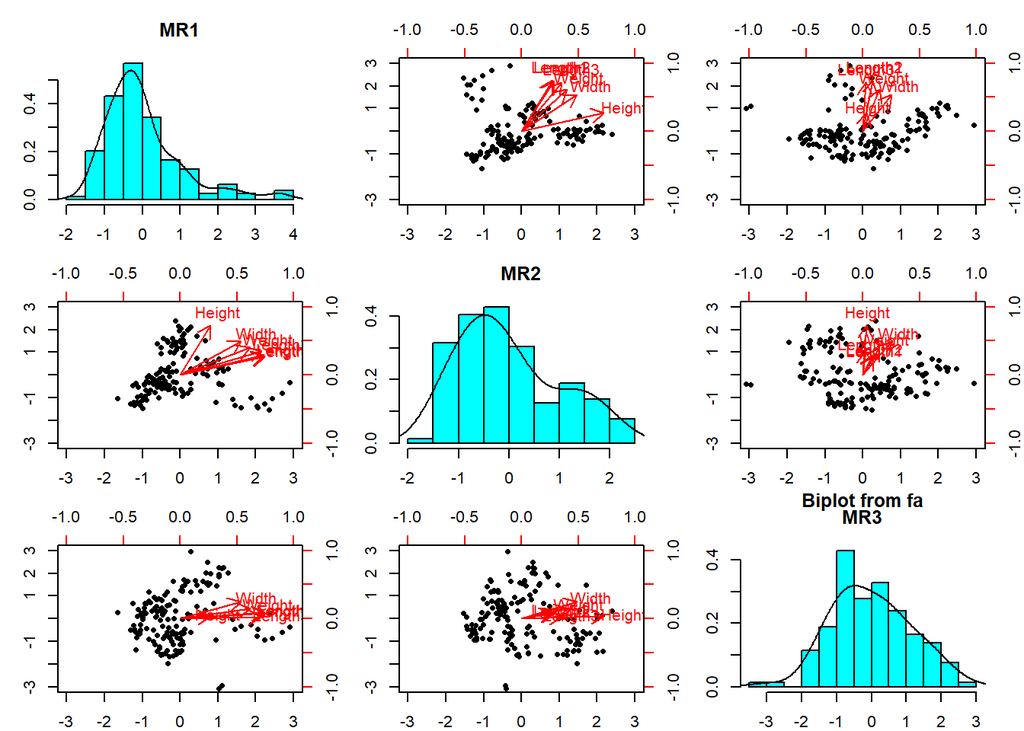

```r
# Biplot of factor loadings
biplot(fa_result_fish)
```

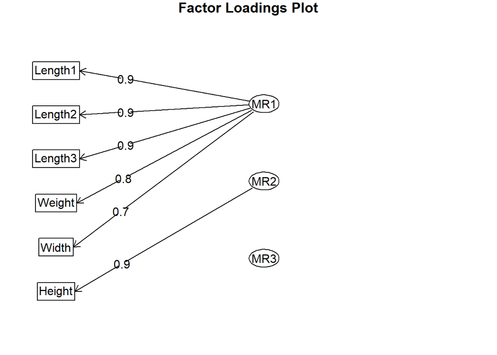

```r
# Factor loadings plot
factor_loading_plot <- fa.diagram(fa_result_fish, main = "Factor Loadings Plot")
```

```r
#1. Kaiser's Criterion:
# Extract eigenvalues from FA results
eigenvalues <- fa_result_fish$values
print(eigenvalues)
```

```
## [1]  5.2278306550  0.4628625208  0.0562876334 -0.0005919724 -0.0017510399
## [6] -0.0034375370
```

```r
# Retain factors with eigenvalues greater than 1
num_factors_kaiser <- sum(eigenvalues > 1)
print(num_factors_kaiser)
```

```
## [1] 1
```

```r
# Factor loadings
fa_loadings <- fa_result_fish$loadings
# Interpret factor loadings
print(fa_loadings)
```

```
##
## Loadings:
##         MR1   MR2   MR3
## Weight  0.775 0.503 0.188
## Length1 0.933 0.340 0.109
## Length2 0.926 0.359 0.106
## Length3 0.896 0.442
## Height  0.334 0.907
## Width   0.669 0.612 0.314
##
##                  MR1   MR2   MR3
## SS loadings    3.692 1.890 0.160
## Proportion Var 0.615 0.315 0.027
## Cumulative Var 0.615 0.930 0.957
```

```r
# Access communalities
communalities <- fa_result_fish$communality
# Interpret communalities
print(communalities)
```

```
##    Weight   Length1   Length2   Length3    Height     Width
## 0.8888754 0.9987517 0.9984450 0.9989453 0.9359486 0.9202343
```

Factor Loadings:

The factor loadings represent the relationships between the original variables (fish characteristics) and the extracted factors. Higher absolute values in the loading matrix indicate stronger correlations between variables and factors.

In this case, it seems that the first factor (MR1) is primarily influenced by variables like Weight, Length1, Length2, and Length3, as they have relatively high loadings on MR1.

The second factor (MR2) is strongly correlated with Height and moderately correlated with Width, while the third factor (MR3) has relatively lower loadings across all variables.

Eigenvalues:

The eigenvalues represent the amount of variance explained by each factor. In this case, only the first factor has an eigenvalue greater than 1, suggesting that it explains a significant amount of variance in the data.

Kaiser’s Criterion:

Kaiser’s Criterion suggests retaining factors with eigenvalues greater than 1. In this case, only one factor meets this criterion, indicating that a one-factor solution might be appropriate.

Communalities:

Communalities represent the proportion of variance in each variable that is accounted for by the extracted factors. Higher communalities indicate that the variable is well-represented by the factors.

All variables in this dataset have relatively high communalities, indicating that they are well-represented by the extracted factors.

Interpretation:

The Factor Analysis suggests that the fish characteristics are primarily influenced by one dominant factor (MR1), which represents overall size or growth of the fish. The other factors (MR2 and MR3) have relatively lower loadings and explain less variance in the data, suggesting that they may not be as meaningful in explaining the variation in fish characteristics.

```r
library(cluster)

#The dataset is of 160 observations that's why we'll create a sample data of 30 rows.
# Set the size of the subset you want
subset_size <- 20  # Adjust this to your desired subset size
# Randomly select subset_size number of rows from your dataset
subset_indices <- sample(nrow(scaled_fish_data), subset_size)
# Create the subset of your dataset
subset_data <- scaled_fish_data[subset_indices, ]

# Perform hierarchical clustering
dist_matrix <- dist(subset_data)
colnames(dist_matrix) <- rownames(dist_matrix)
print(dist_matrix)
```

```
##             1          2          3          4          5          6          7
## 2  2.01209931
## 3  0.95415276 1.44335743
## 4  4.57663308 3.50568778 3.71173843
## 5  3.52501869 2.57922195 2.63097856 1.12184559
## 6  1.87091698 0.34639808 1.28011765 3.62775818 2.64686673
## 7  6.60701868 5.53774951 5.77417145 2.13911560 3.23097404 5.68625242
## 8  4.22199156 3.13662953 3.35122078 0.38048426 0.77323628 3.25493078 2.51370492
## 9  2.24459197 1.52315686 1.32902538 2.44953901 1.35481831 1.49600082 4.56185318
## 10 6.56719230 5.48320469 5.72638356 2.09457290 3.17976320 5.62777656 0.14089730
## 11 6.57463211 5.48982041 5.73499188 2.10180201 3.18884450 5.63552039 0.12052260
## 12 2.82743814 1.24701008 1.96477493 2.33252204 1.47311544 1.35310148 4.37246722
## 13 3.30565965 2.34039311 2.39706891 1.36864532 0.27287231 2.39414780 3.47504549
## 14 2.49841489 0.81693710 1.70304355 2.71352918 1.82570838 0.96222779 4.75422895
## 15 0.38486693 1.74219725 0.87391022 4.52048919 3.45654951 1.58043709 6.58500714
## 16 1.95431406 0.42371829 1.39000533 3.69967871 2.73655827 0.23764235 5.73057661
## 17 4.30710436 3.30258353 3.44000629 0.30936179 0.84138018 3.40939389 2.41592484
## 18 2.11004993 3.08893709 1.99582237 4.90761599 3.85147653 2.80183161 6.81226405
## 19 2.10791984 0.26715637 1.45780321 3.34815710 2.42450617 0.41488057 5.36659073
## 20 4.24220554 3.25783489 3.38303148 0.37988472 0.81093293 3.36671727 2.46644413
##             8          9         10         11         12         13         14
## 2
## 3
## 4
## 5
## 6
## 7
## 8
## 9  2.08126378
## 10 2.46757662 4.51213433
## 11 2.47484420 4.52073816 0.02516689
## 12 1.96931390 1.02088146 4.31119355 4.31901162
## 13 1.01131396 1.11702186 3.41985846 3.42941440 1.25024068
## 14 2.34647341 1.05796390 4.69764160 4.70464537 0.44257425 1.59657222
## 15 4.15526472 2.13822018 6.54166157 6.54917509 2.63696703 3.22553547 2.28809289
## 16 3.33171776 1.63179191 5.66828609 5.67645964 1.41211861 2.48110016 1.03668696
## 17 0.22497686 2.17498619 2.37280664 2.38057262 2.14427956 1.09953891 2.51821302
## 18 4.59702808 2.80872805 6.74317628 6.75723742 3.44099455 3.62600468 3.30547357
## 19 2.98251551 1.41941393 5.30770890 5.31506224 1.07788601 2.18054064 0.67476384
## 20 0.25438778 2.12375990 2.42721091 2.43429430 2.11476239 1.07104410 2.47888331
##            15         16         17         18         19
## 2
## 3
## 4
## 5
## 6
## 7
## 8
## 9
## 10
## 11
## 12
## 13
## 14
## 15
## 16 1.66997752
## 17 4.25423601 3.49053056
## 18 2.17029178 2.79974421 4.63327281
## 19 1.85934755 0.41147871 3.14879988 3.02450921
## 20 4.19405999 3.45135934 0.12298523 4.59570702 3.10742339
```

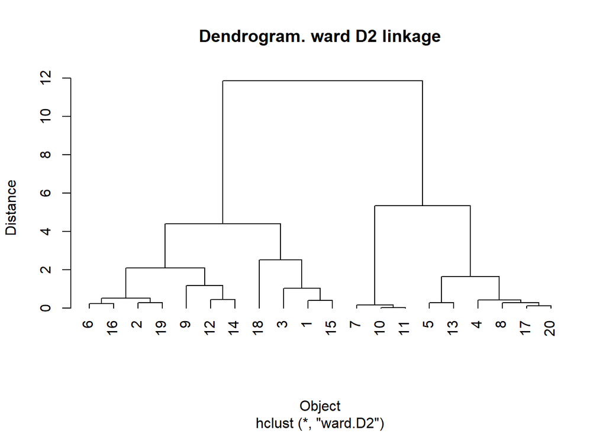

```r
# Clustering
hclust_result <- hclust(dist_matrix, method = "ward.D2")
plot(hclust_result, hang=-1,xlab="Object",ylab="Distance",
     main="Dendrogram. ward D2 linkage")
```

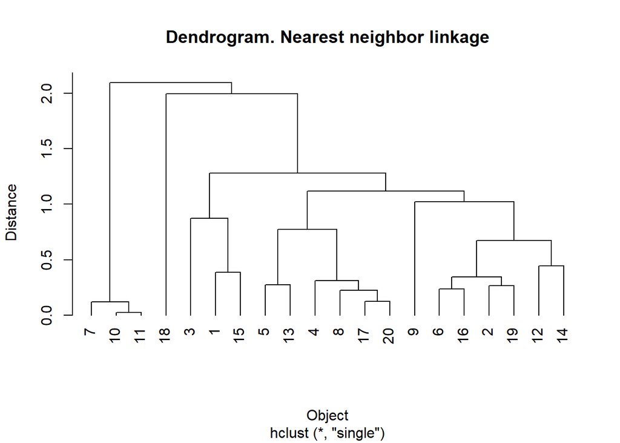

```r
# Invoking hclust command (cluster analysis by single linkage method)
clus_fish.1 <- hclust(dist_matrix, method = "single")
plot(clus_fish.1, hang=-1,xlab="Object",ylab="Distance",
     main="Dendrogram. Nearest neighbor linkage")
```

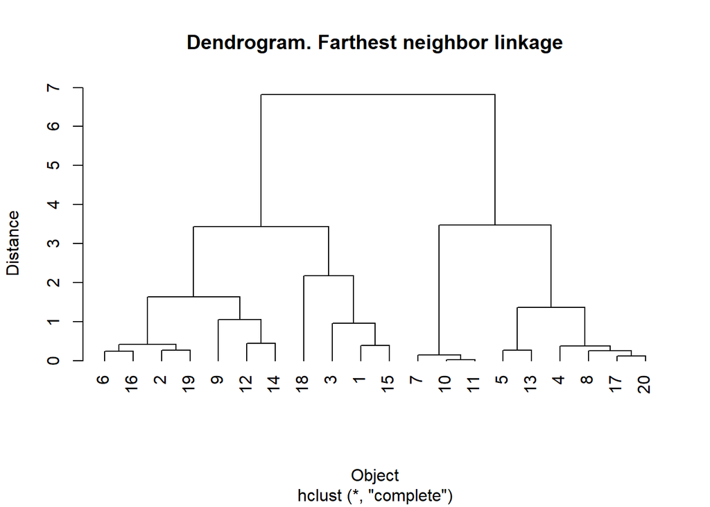

```r
#Default - Complete
clus_fish.2 <- hclust(dist_matrix)
plot(clus_fish.2,hang=-1,xlab="Object",ylab="Distance",
     main="Dendrogram. Farthest neighbor linkage")
```

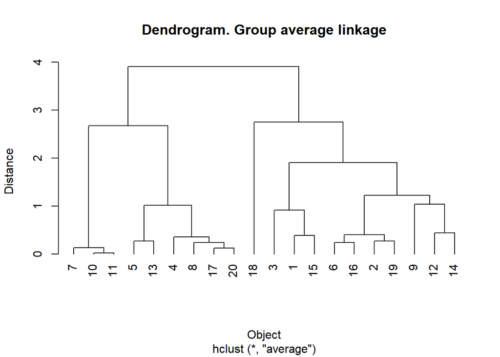

```r
#Average
clus_fish.3 <- hclust(dist_matrix,method="average")
plot(clus_fish.3,hang=-1,xlab="Object",ylab="Distance",
     main="Dendrogram. Group average linkage")
```

```r
# We will use agnes function as it allows us to select option for data standardization, the distance measure and clustering algorithm in one single function
(agn.fish <- agnes(subset_data, metric="euclidean", stand=TRUE, method = "single"))
```

```
## Call:     agnes(x = subset_data, metric = "euclidean", stand = TRUE, method = "single")
## Agglomerative coefficient:  0.8090936
## Order of objects:
##  [1]  1 15  3  2 19  6 16 12 14  9  4  8 17 20  5 13  7 10 11 18
## Height (summary):
##    Min. 1st Qu.  Median    Mean 3rd Qu.    Max.
## 0.03452 0.31149 0.47713 0.84879 1.16060 2.68622
##
## Available components:
## [1] "order"  "height" "ac"     "merge"  "diss"   "call"   "method" "data"
```

```r
#  Description of cluster merging
agn.fish$merge
```

```
##       [,1] [,2]
##  [1,]  -10  -11
##  [2,]   -7    1
##  [3,]  -17  -20
##  [4,]   -8    3
##  [5,]   -6  -16
##  [6,]   -2  -19
##  [7,]   -5  -13
##  [8,]   -4    4
##  [9,]   -1  -15
## [10,]    6    5
## [11,]  -12  -14
## [12,]   10   11
## [13,]    8    7
## [14,]    9   -3
## [15,]   12   -9
## [16,]   15   13
## [17,]   14   16
## [18,]   17    2
## [19,]   18  -18
```

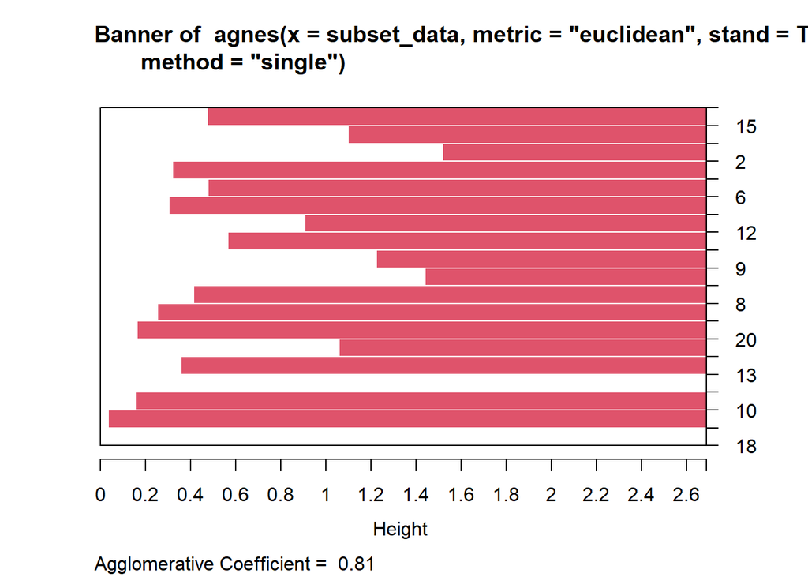

```r
#Interactive Plots
plot(agn.fish, which.plots=1)
```

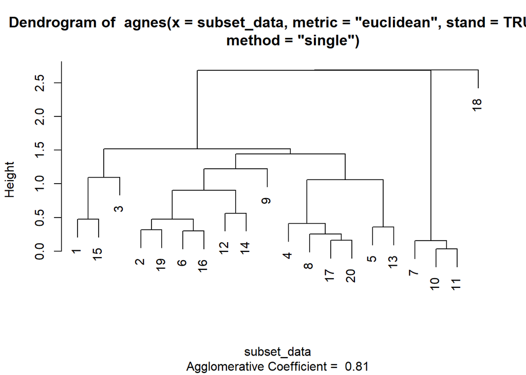

```r
plot(agn.fish, which.plots=2)
```

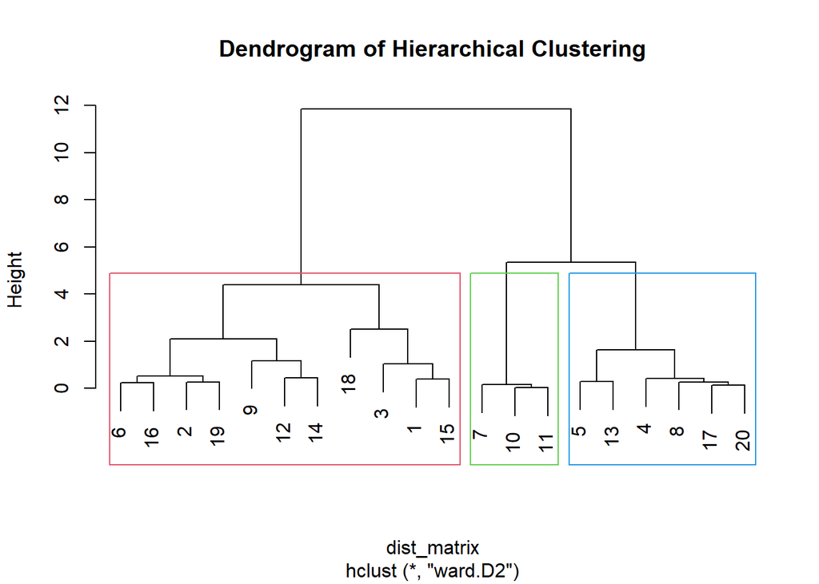

```r
# Cut the dendrogram to obtain clusters
num_clusters <- 3  # Choose the number of clusters
clusters <- cutree(hclust_result, k = num_clusters)

# Visualize the dendrogram
plot(hclust_result, main = "Dendrogram of Hierarchical Clustering")
rect.hclust(hclust_result, k = num_clusters, border = 2:5)
```

```r
# K-means, k=2, 3, 4, 5, 6
# Centers (k's) are numbers thus, 10 random sets are chosen

# Computing the percentage of variation accounted for. Two clusters
(kmeans2.fish <- kmeans(subset_data,2,nstart = 10))
```

```
## K-means clustering with 2 clusters of sizes 9, 11
##
## Cluster means:
##       Weight    Length1    Length2    Length3     Height      Width
## 1 -0.7971432 -0.7972816 -0.8137093 -0.8602461 -0.9086702 -0.8920733
## 2  0.6020008  0.6127233  0.6164905  0.6717230  0.8429281  0.7674831
##
## Clustering vector:
##  [1] 2 2 2 1 1 2 1 1 2 1 1 2 1 2 2 2 1 2 2 1
##
## Within cluster sum of squares by cluster:
## [1] 15.81083 16.54190
##  (between_SS / total_SS =  68.4 %)
##
## Available components:
##
## [1] "cluster"      "centers"      "totss"        "withinss"     "tot.withinss"
## [6] "betweenss"    "size"         "iter"         "ifault"
```

```r
# Computing the percentage of variation accounted for. Two clusters
perc.var.2 <- round(100*(1 - kmeans2.fish$betweenss/kmeans2.fish$totss),1)
names(perc.var.2) <- "Perc. 2 clus"
perc.var.2
```

```
## Perc. 2 clus
##         31.6
```

```r
# Computing the percentage of variation accounted for. Three clusters
(kmeans3.fish <- kmeans(subset_data,3,nstart = 10))
```

```
## K-means clustering with 3 clusters of sizes 3, 11, 6
##
## Cluster means:
##       Weight    Length1    Length2   Length3     Height      Width
## 1 -1.0941661 -1.5109106 -1.5622700 -1.575020 -1.5958832 -1.9090466
## 2  0.6020008  0.6127233  0.6164905  0.671723  0.8429281  0.7674831
## 3 -0.6486317 -0.4404671 -0.4394290 -0.502859 -0.5650637 -0.3835867
##
## Clustering vector:
##  [1] 2 2 2 3 3 2 1 3 2 1 1 2 3 2 2 2 3 2 2 3
##
## Within cluster sum of squares by cluster:
## [1]  0.01167037 16.54190049  1.51062162
##  (between_SS / total_SS =  82.4 %)
##
## Available components:
##
## [1] "cluster"      "centers"      "totss"        "withinss"     "tot.withinss"
## [6] "betweenss"    "size"         "iter"         "ifault"
```

```r
# Computing the percentage of variation accounted for. Two clusters
perc.var.3 <- round(100*(1 - kmeans3.fish$betweenss/kmeans3.fish$totss),1)
names(perc.var.3) <- "Perc. 3 clus"
perc.var.3
```

```
## Perc. 3 clus
##         17.6
```

```r
# Computing the percentage of variation accounted for. Four clusters
(kmeans4.fish <- kmeans(subset_data,4,nstart = 10))
```

```
## K-means clustering with 4 clusters of sizes 4, 6, 3, 7
##
## Cluster means:
##       Weight    Length1    Length2    Length3     Height      Width
## 1  1.1019149  1.1818457  1.1446621  1.0337142  0.3418032  1.3159298
## 2 -0.6486317 -0.4404671 -0.4394290 -0.5028590 -0.5650637 -0.3835867
## 3 -1.0941661 -1.5109106 -1.5622700 -1.5750202 -1.5958832 -1.9090466
## 4  0.3163356  0.2875105  0.3146782  0.4648708  1.1292852  0.4540850
##
## Clustering vector:
##  [1] 1 4 1 2 2 4 3 2 4 3 3 4 2 4 1 4 2 1 4 2
##
## Within cluster sum of squares by cluster:
## [1] 3.74200830 1.51062162 0.01167037 3.14668714
##  (between_SS / total_SS =  91.8 %)
##
## Available components:
##
## [1] "cluster"      "centers"      "totss"        "withinss"     "tot.withinss"
## [6] "betweenss"    "size"         "iter"         "ifault"
```

```r
perc.var.4 <- round(100*(1 - kmeans4.fish$betweenss/kmeans4.fish$totss),1)
names(perc.var.4) <- "Perc. 4 clus"
perc.var.4
```

```
## Perc. 4 clus
##          8.2
```

```r
# Computing the percentage of variation accounted for. Five clusters
(kmeans5.fish <- kmeans(subset_data,5,nstart = 10))
```

```
## K-means clustering with 5 clusters of sizes 4, 6, 3, 4, 3
##
## Cluster means:
##         Weight    Length1    Length2    Length3     Height      Width
## 1  0.553267406  0.4102274  0.4341506  0.6123032  1.4607290  0.5777754
## 2 -0.648631716 -0.4404671 -0.4394290 -0.5028590 -0.5650637 -0.3835867
## 3  0.000426426  0.1238880  0.1553817  0.2682943  0.6873602  0.2891645
## 4  1.101914903  1.1818457  1.1446621  1.0337142  0.3418032  1.3159298
## 5 -1.094166099 -1.5109106 -1.5622700 -1.5750202 -1.5958832 -1.9090466
##
## Clustering vector:
##  [1] 4 1 4 2 2 1 5 2 3 5 5 3 2 3 4 1 2 4 1 2
##
## Within cluster sum of squares by cluster:
## [1] 0.19220396 1.51062162 0.78578618 3.74200830 0.01167037
##  (between_SS / total_SS =  93.9 %)
##
## Available components:
##
## [1] "cluster"      "centers"      "totss"        "withinss"     "tot.withinss"
## [6] "betweenss"    "size"         "iter"         "ifault"
```

```r
perc.var.5 <- round(100*(1 - kmeans5.fish$betweenss/kmeans5.fish$totss),1)
names(perc.var.5) <- "Perc. 5 clus"
perc.var.5
```

```
## Perc. 5 clus
##          6.1
```

```r
# Computing the percentage of variation accounted for. Six clusters
(kmeans6.fish <- kmeans(subset_data,6,nstart = 10))
```

```
## K-means clustering with 6 clusters of sizes 1, 3, 3, 3, 6, 4
##
## Cluster means:
##         Weight    Length1    Length2    Length3     Height      Width
## 1  1.032023502  1.8485838  1.8202303  1.7131318 -0.3042449  0.5635067
## 2  1.125212036  0.9595996  0.9194726  0.8072416  0.5571526  1.5667375
## 3  0.000426426  0.1238880  0.1553817  0.2682943  0.6873602  0.2891645
## 4 -1.094166099 -1.5109106 -1.5622700 -1.5750202 -1.5958832 -1.9090466
## 5 -0.648631716 -0.4404671 -0.4394290 -0.5028590 -0.5650637 -0.3835867
## 6  0.553267406  0.4102274  0.4341506  0.6123032  1.4607290  0.5777754
##
## Clustering vector:
##  [1] 2 6 2 5 5 6 4 5 3 4 4 3 5 3 2 6 5 1 6 5
##
## Within cluster sum of squares by cluster:
## [1] 0.00000000 0.60741637 0.78578618 0.01167037 1.51062162 0.19220396
##  (between_SS / total_SS =  97.0 %)
##
## Available components:
##
## [1] "cluster"      "centers"      "totss"        "withinss"     "tot.withinss"
## [6] "betweenss"    "size"         "iter"         "ifault"
```

```r
perc.var.6 <- round(100*(1 - kmeans6.fish$betweenss/kmeans6.fish$totss),1)
names(perc.var.6) <- "Perc. 6 clus"
perc.var.6
```

```
## Perc. 6 clus
##            3
```

```r
Variance_List <- c(perc.var.2,perc.var.3,perc.var.4,perc.var.5,perc.var.6)
Variance_List
```

```
## Perc. 2 clus Perc. 3 clus Perc. 4 clus Perc. 5 clus Perc. 6 clus
##         31.6         17.6          8.2          6.1          3.0
```

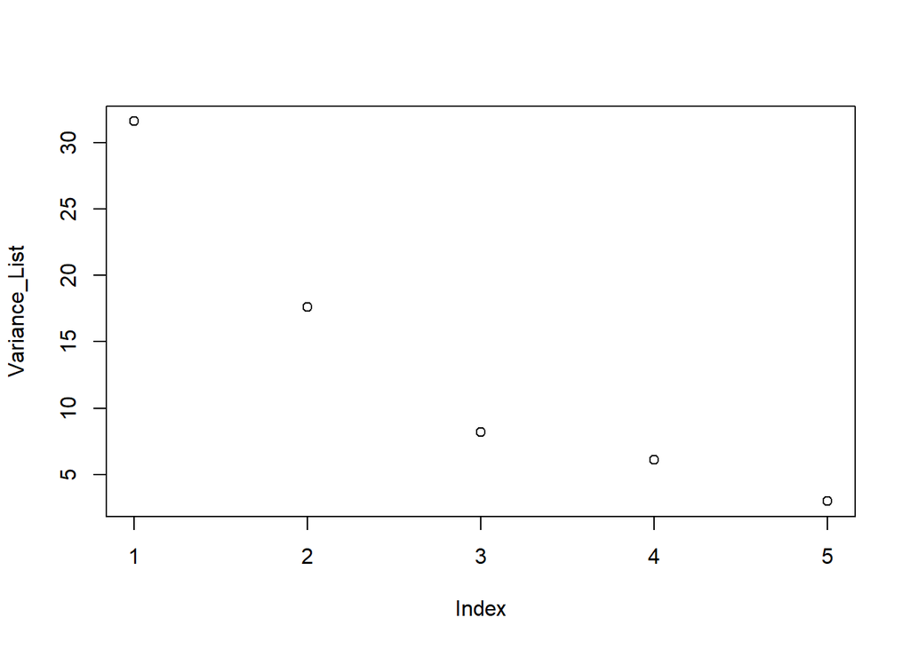

```r
plot(Variance_List)
```

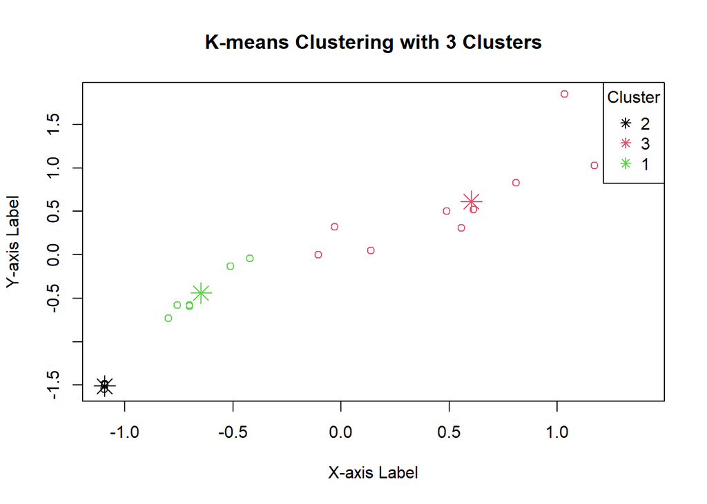

```r
# Plot clusters
plot(subset_data, col = kmeans3.fish$cluster,
      main = "K-means Clustering with 3 Clusters",
      xlab = "X-axis Label", ylab = "Y-axis Label")

# Add cluster centers to the plot
points(kmeans3.fish$centers, col = 1:3, pch = 8, cex = 2)

# Add legend
legend("topright", legend = unique(kmeans3.fish$cluster),
        col = 1:3, pch = 8, title = "Cluster")
```

These cluster assignments can be further investigated to understand the factors driving the differences between the clusters, such as environmental conditions, feeding regimes, or genetic factors.

Models:

Multiple Linear Regression:

```r
fish_data <- read.csv("C:/Users/HP/Desktop/USA/Spring'24/Multivariate/Datasets/Fish_dataset.csv")
str(fish_data)
```

```
## 'data.frame':    158 obs. of  7 variables:
##  $ Species: chr  "Bream" "Bream" "Bream" "Bream" ...
##  $ Weight : num  242 290 340 363 430 450 500 390 450 500 ...
##  $ Length1: num  23.2 24 23.9 26.3 26.5 26.8 26.8 27.6 27.6 28.5 ...
##  $ Length2: num  25.4 26.3 26.5 29 29 29.7 29.7 30 30 30.7 ...
##  $ Length3: num  30 31.2 31.1 33.5 34 34.7 34.5 35 35.1 36.2 ...
##  $ Height : num  11.5 12.5 12.4 12.7 12.4 ...
##  $ Width  : num  4.02 4.31 4.7 4.46 5.13 ...
```

```r
# Fit linear regression model
sm_model_fit <- lm(Weight ~ Length1 + Height + Width, data = fish_data)

#show the results
summary(sm_model_fit)
```

```
##
## Call:
## lm(formula = Weight ~ Length1 + Height + Width, data = fish_data)
##
## Residuals:
##     Min      1Q  Median      3Q     Max
## -249.24  -73.13  -27.96   75.11  443.17
##
## Coefficients:
##             Estimate Std. Error t value Pr(>|t|)
## (Intercept) -511.471     28.593 -17.888  < 2e-16 ***
## Length1       22.605      2.019  11.198  < 2e-16 ***
## Height        13.590      3.848   3.532 0.000545 ***
## Width         44.266     15.321   2.889 0.004420 **
## ---
## Signif. codes:  0 '***' 0.001 '**' 0.01 '*' 0.05 '.' 0.1 ' ' 1
##
## Residual standard error: 123.6 on 154 degrees of freedom
## Multiple R-squared:  0.8828, Adjusted R-squared:  0.8805
## F-statistic: 386.7 on 3 and 154 DF,  p-value: < 2.2e-16
```

```r
#Summary has three sections. Section1: How well does the model fit the data (before Coefficients). Section2: Is the hypothesis supported? (until sifnif codes). Section3: How well does data fit the model (again).
# Useful Helper Functions
coefficients(sm_model_fit)
```

```
## (Intercept)     Length1      Height       Width
##  -511.47059    22.60470    13.58978    44.26608
```

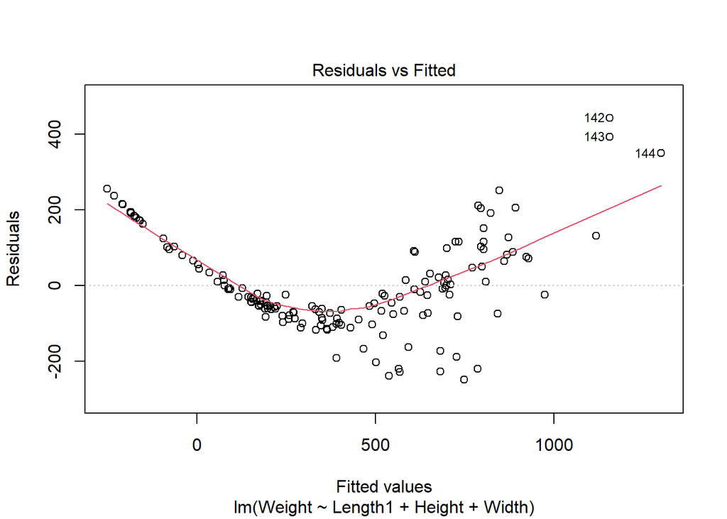

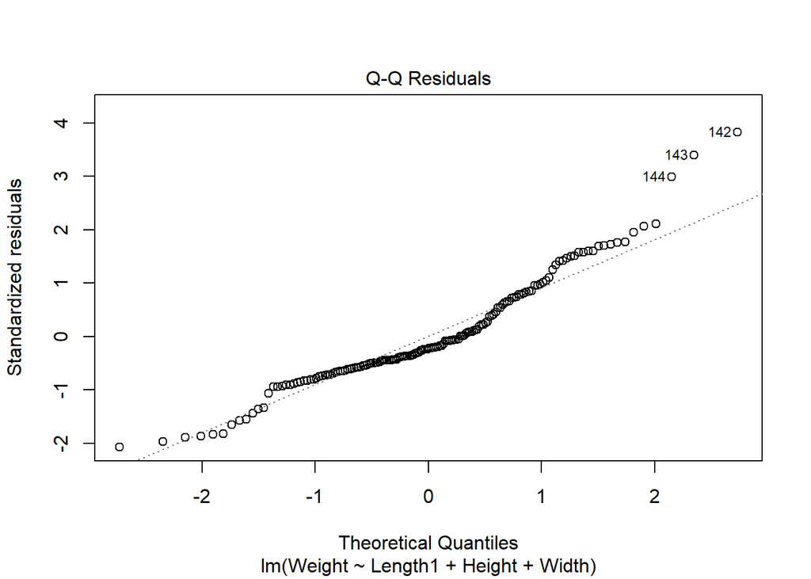

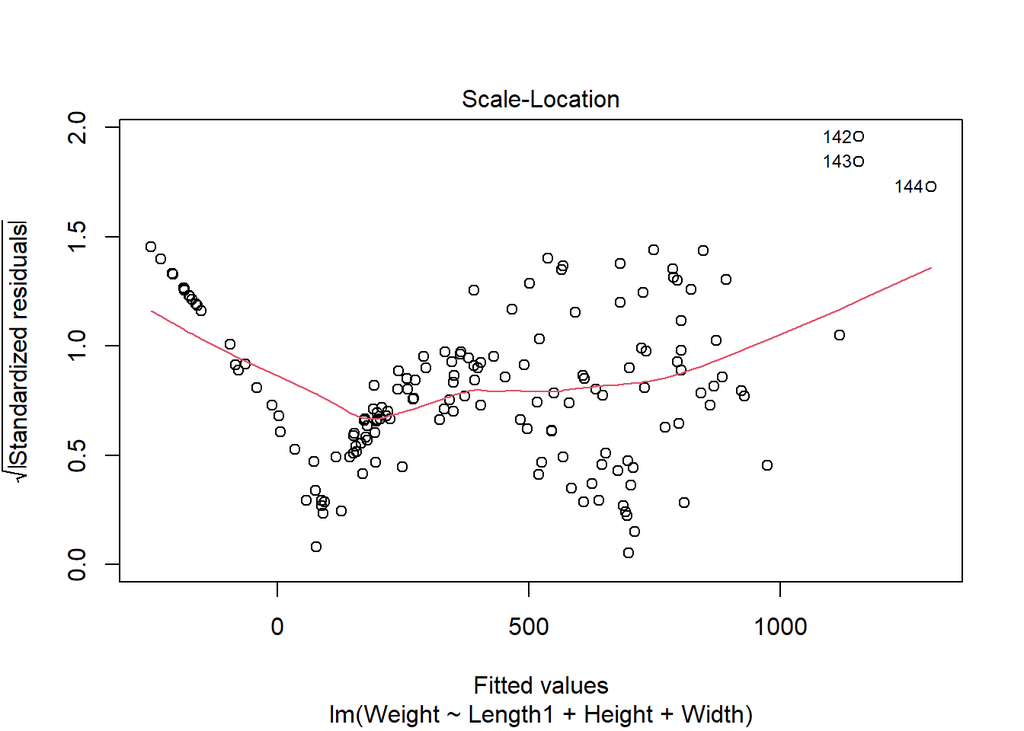

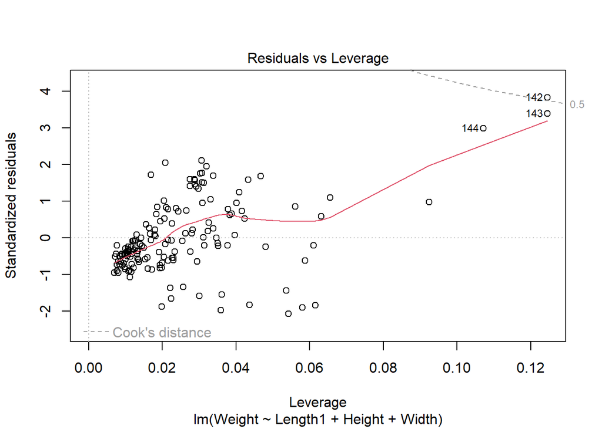

```r
# Diagnostic plots for the linear regression model
plot(sm_model_fit)
```

```r
# Assess the acceptance of the model
# Check R-squared and adjusted R-squared
r_squared <- summary(sm_model_fit)$r.squared
adj_r_squared <- summary(sm_model_fit)$adj.r.squared
cat("R-squared:", r_squared, "\n")
```

[output not shown]

```r
cat("Adjusted R-squared:", adj_r_squared, "\n")
```

```
## Adjusted R-squared: 0.8805169
```

```r
# Check the F-statistic and its p-value
f_statistic <- summary(sm_model_fit)$fstatistic
f_statistic_value <- f_statistic[1]
f_statistic_p_value <- pf(f_statistic_value, f_statistic[2], f_statistic[3], lower.tail = FALSE)
cat("F-statistic:", f_statistic_value, "\n")
```

```
## F-statistic: 386.6645
```

```r
cat("p-value:", f_statistic_p_value, "\n")
```

```
## p-value: 1.899006e-71
```

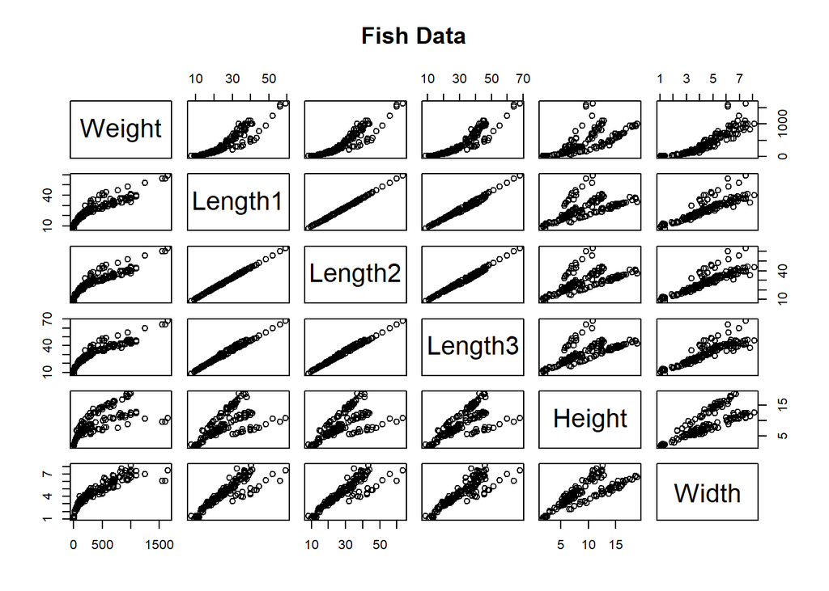

```r
# Reset plotting parameters
par(mfrow = c(1, 1))

# Select only numeric variables from fish_data
numeric_fish_data <- fish_data[, sapply(fish_data, is.numeric)]
# Plot pairs
pairs(numeric_fish_data, main = "Fish Data")
```

```r
confint(sm_model_fit,level=0.95)
```

```
##                   2.5 %     97.5 %
## (Intercept) -567.955292 -454.98588
## Length1       18.616875   26.59252
## Height         5.988356   21.19120
## Width         13.998732   74.53344
```

```r
fitted(sm_model_fit)
```

```
##           1           2           3           4           5           6
##  347.462289  391.234627  404.871188  453.258362  483.927163  497.305597
##           7           8           9          10          11          12
##  520.690080  492.209479  517.158596  545.632837  550.274046  545.711847
##          13          14          15          16          17          18
##  526.664831  568.994195  585.225554  609.911252  611.625706  608.789284
##          19          20          21          22          23          24
##  626.716778  639.509179  648.189348  653.392956  645.256773  688.951280
##          25          26          27          28          29          30
##  677.727187  697.639012  703.813405  711.188366  733.868291  795.697142
##          31          32          33          34          35          36
##  803.966487  803.973561  860.467653  885.872586  869.004449  -63.114984
##          37          38          39          40          41          42
##   58.415250   88.449198  116.790363  151.666682  154.411149  155.982360
##          43          44          45          46          47          48
##  194.739693  199.126151  216.617775  199.425834  220.674227  257.992864
##          49          50          51          52          53          54
##  240.549152  271.309077  291.208917  350.731617  381.392644  521.311910
##          55          56          57          58          59          60
##  323.912665  332.061255  393.736836  569.245906  701.127341  788.408941
##          61          62          63          64          65          66
##  -10.266125    3.599844   75.944245  127.332610  171.066382  179.872937
##          67          68          69          70          71          72
##  196.673268  208.170387  270.519345  342.559560  372.953343 -250.907098
##          73          74          75          76          77          78
##  -92.470377  -39.903335    6.500198   35.981751   72.730993   77.204990
##          79          80          81          82          83          84
##   88.939889   95.139115   91.703743  152.744404  144.846248  157.724339
##          85          86          87          88          89          90
##  167.993556  174.493586  173.307656  179.694851  176.501253  192.515917
##          91          92          93          94          95          96
##  191.927739  204.647770  198.035201  194.655137  224.697428  249.745637
##          97          98          99         100         101         102
##  241.785363  275.304639  259.002950  296.546266  334.497029  398.683663
##         103         104         105         106         107         108
##  351.982859  350.411880  363.788156  366.372046  404.867964  431.654361
##         109         110         111         112         113         114
##  580.671450  634.012899  724.391995  708.801899  699.653257  692.946028
##         115         116         117         118         119         120
##  696.143450  796.648264  730.674092  810.217634  799.322272  804.133769
##         121         122         123         124         125         126
##  823.486765  771.970002  848.101658  872.493619  893.319288  928.938266
##         127         128         129         130         131         132
##  923.538816  391.762815  466.724436  502.457598  538.571650  592.649388
##         133         134         135         136         137         138
##  565.264959  682.991044  682.850016  727.855098  749.238310  786.519724
##         139         140         141         142         143         144
##  843.563823  974.816235 1118.392296 1156.825161 1156.825161 1300.249552
##         145         146         147         148         149         150
## -231.243844 -207.275912 -208.839398 -185.451384 -184.753455 -183.565783
##         151         152         153         154         155         156
## -169.122297 -174.341268 -172.984558 -161.419279 -157.798805 -151.420474
##         157         158
##  -82.541017  -76.492989
```

```r
residuals(sm_model_fit)
```

```
##            1            2            3            4            5            6
## -105.4622890 -101.2346268  -64.8711878  -90.2583616  -53.9271631  -47.3055971
##            7            8            9           10           11           12
##  -20.6900797 -102.2094786  -67.1585958  -45.6328365  -75.2740457  -45.7118467
##           13           14           15           16           17           18
##  -26.6648310 -228.9941950   14.7744457   -9.9112523   88.3742938   91.2107160
##           19           20           21           22           23           24
##  -16.7167783   10.4908206  -73.1893478   31.6070437  -25.2567726   -8.9512797
##           25           26           27           28           29           30
##   22.2728129   27.3609879   16.1865949    2.8116343  116.1317090  204.3028578
##           31           32           33           34           35           36
##  116.0335125  151.0264390   64.5323465   89.1274135   80.9955510  103.1149843
##           37           38           39           40           41           42
##   10.5847497  -10.4491983  -29.7903635  -31.6666822  -44.4111487  -35.9823598
##           43           44           45           46           47           48
##  -44.7396930  -54.1261508  -56.6177747  -59.4258337  -60.6742270  -88.9928641
##           49           50           51           52           53           54
##  -79.5491519  -71.3090772 -111.2089168  -60.7316174 -109.3926440 -131.3119102
##           55           56           57           58           59           60
##  -53.9126648  -62.0612555  -87.7368360  -29.2459058   98.8726589  211.5910595
##           61           62           63           64           65           66
##   65.2661248   56.4001563   14.0557546   -7.3326097  -21.0663818  -39.8729372
##           67           68           69           70           71           72
##  -26.6732677  -63.1703867  -70.5193452  -69.5595603  -72.9533431  256.8070981
##           73           74           75           76           77           78
##  124.4703768   79.9033346   44.9998023   34.0182495   27.2690074    0.7950096
##           79           80           81           82           83           84
##   -8.9398887  -10.1391148   -6.7037431  -42.7444041  -29.8462481  -32.7243386
##           85           86           87           88           89           90
##  -37.9935565  -54.4935862  -53.3076559  -49.6948511  -41.5012535  -82.5159167
##           91           92           93           94           95           96
##  -61.9277389  -54.6477702  -53.0352012  -44.6551369  -54.6974276  -24.7456372
##           97           98           99          100          101          102
##  -96.7853625  -87.3046387  -79.0029498  -99.5462664 -116.4970294  -98.6836631
##          103          104          105          106          107          108
##  -91.9828587  -85.4118805 -113.7881557 -116.3720461 -104.8679637 -111.6543614
##          109          110          111          112          113          114
##  -66.6714502  -78.0128993  115.6080055  -23.8018995    0.3467425    7.0539725
##          115          116          117          118          119          120
##   -6.1434496  103.3517360  -80.6740918    9.7823659   50.6777282   95.8662306
##          121          122          123          124          125          126
##  191.5132352   48.0299984  251.8983417  127.5063809  206.6807123   71.0617337
##          127          128          129          130          131          132
##   76.4611835 -191.7628148 -166.7244359 -202.4575981 -238.5716501 -162.6493883
##          133          134          135          136          137          138
## -220.2649588 -226.9910443 -172.8500162 -187.8550980 -249.2383102 -219.5197236
##          139          140          141          142          143          144
##  -73.5638234  -24.8162355  131.6077040  443.1748388  393.1748388  349.7504475
##          145          146          147          148          149          150
##  237.9438441  214.7759119  215.8393984  195.1513842  194.5534553  192.2657834
##          151          152          153          154          155          156
##  179.1222967  184.2412680  182.7845576  173.6192786  171.1988049  163.6204741
##          157          158
##  102.2410166   96.3929892
```

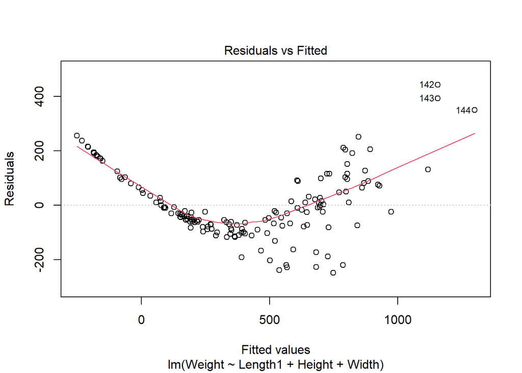

```r
# Plot residuals vs. fitted values
plot(sm_model_fit, which = 1)
```

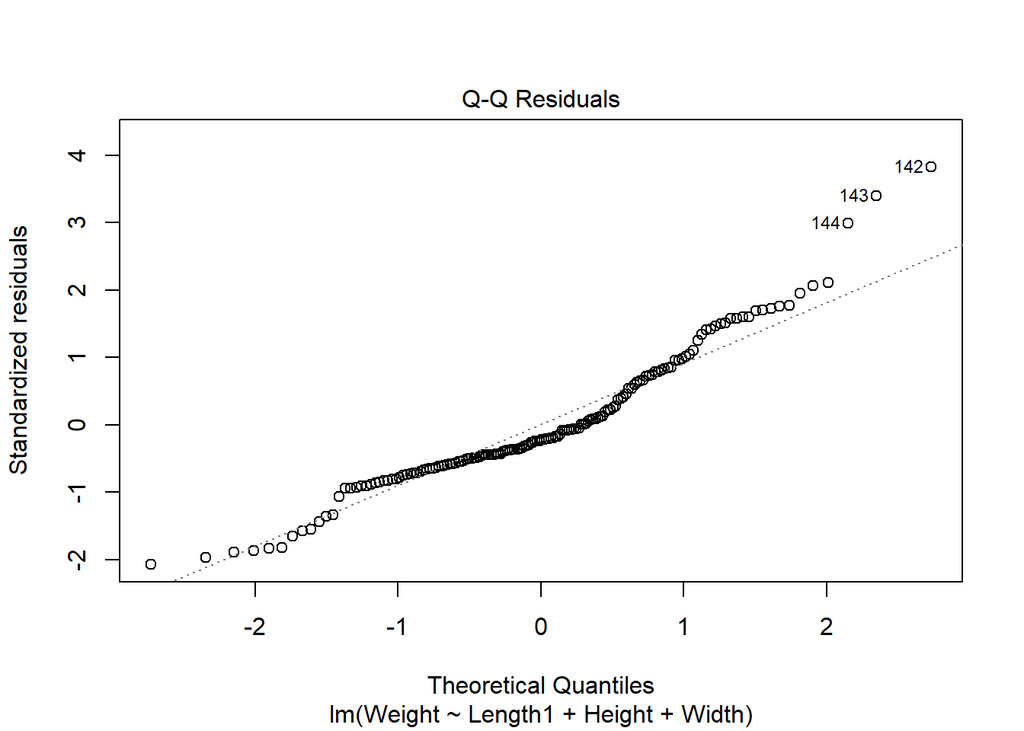

```r
# Plot normal Q-Q plot of residuals
plot(sm_model_fit, which = 2)
```

```r
# Make predictions
predictions <- predict(sm_model_fit, newdata = fish_data)

# Print predictions
print(predictions)
```

```
##           1           2           3           4           5           6
##  347.462289  391.234627  404.871188  453.258362  483.927163  497.305597
##           7           8           9          10          11          12
##  520.690080  492.209479  517.158596  545.632837  550.274046  545.711847
##          13          14          15          16          17          18
##  526.664831  568.994195  585.225554  609.911252  611.625706  608.789284
##          19          20          21          22          23          24
##  626.716778  639.509179  648.189348  653.392956  645.256773  688.951280
##          25          26          27          28          29          30
##  677.727187  697.639012  703.813405  711.188366  733.868291  795.697142
##          31          32          33          34          35          36
##  803.966487  803.973561  860.467653  885.872586  869.004449  -63.114984
##          37          38          39          40          41          42
##   58.415250   88.449198  116.790363  151.666682  154.411149  155.982360
##          43          44          45          46          47          48
##  194.739693  199.126151  216.617775  199.425834  220.674227  257.992864
##          49          50          51          52          53          54
##  240.549152  271.309077  291.208917  350.731617  381.392644  521.311910
##          55          56          57          58          59          60
##  323.912665  332.061255  393.736836  569.245906  701.127341  788.408941
##          61          62          63          64          65          66
##  -10.266125    3.599844   75.944245  127.332610  171.066382  179.872937
##          67          68          69          70          71          72
##  196.673268  208.170387  270.519345  342.559560  372.953343 -250.907098
##          73          74          75          76          77          78
##  -92.470377  -39.903335    6.500198   35.981751   72.730993   77.204990
##          79          80          81          82          83          84
##   88.939889   95.139115   91.703743  152.744404  144.846248  157.724339
##          85          86          87          88          89          90
##  167.993556  174.493586  173.307656  179.694851  176.501253  192.515917
##          91          92          93          94          95          96
##  191.927739  204.647770  198.035201  194.655137  224.697428  249.745637
##          97          98          99         100         101         102
##  241.785363  275.304639  259.002950  296.546266  334.497029  398.683663
##         103         104         105         106         107         108
##  351.982859  350.411880  363.788156  366.372046  404.867964  431.654361
##         109         110         111         112         113         114
##  580.671450  634.012899  724.391995  708.801899  699.653257  692.946028
##         115         116         117         118         119         120
##  696.143450  796.648264  730.674092  810.217634  799.322272  804.133769
##         121         122         123         124         125         126
##  823.486765  771.970002  848.101658  872.493619  893.319288  928.938266
##         127         128         129         130         131         132
##  923.538816  391.762815  466.724436  502.457598  538.571650  592.649388
##         133         134         135         136         137         138
##  565.264959  682.991044  682.850016  727.855098  749.238310  786.519724
##         139         140         141         142         143         144
##  843.563823  974.816235 1118.392296 1156.825161 1156.825161 1300.249552
##         145         146         147         148         149         150
## -231.243844 -207.275912 -208.839398 -185.451384 -184.753455 -183.565783
##         151         152         153         154         155         156
## -169.122297 -174.341268 -172.984558 -161.419279 -157.798805 -151.420474
##         157         158
##  -82.541017  -76.492989
```

```r
# Calculate Mean Squared Error (MSE)
mse <- mean(sm_model_fit$residuals^2)

# Calculate Root Mean Squared Error (RMSE)
rmse <- sqrt(mse)

# Calculate Mean Absolute Error (MAE)
mae <- mean(abs(sm_model_fit$residuals))

# Print the accuracy metrics
cat("Mean Squared Error (MSE):", mse, "\n")
```

```
## Mean Squared Error (MSE): 14900.56
```

```r
cat("Root Mean Squared Error (RMSE):", rmse, "\n")
```

```
## Root Mean Squared Error (RMSE): 122.0679
```

```r
cat("Mean Absolute Error (MAE):", mae, "\n")
```

```
## Mean Absolute Error (MAE): 94.08461
```

1. Model Fit:

The linear regression model appears to fit the data quite well, as indicated by the high adjusted R-squared value of 0.8805. This suggests that approximately 88.05% of the variability in the response variable (Weight) can be explained by the predictor variables (Length1, Height, Width).

2. Coefficient Estimates:

The coefficients of the predictor variables (Length1, Height, Width) indicate their respective impacts on the response variable (Weight). For example, the coefficient for Length1 is 22.605, suggesting that for every unit increase in Length1, the Weight of the fish is expected to increase by approximately 22.605 units, holding other variables constant.

3. Significance:

All predictor variables (Length1, Height, Width) are statistically significant at the 0.05 significance level, as indicated by their p-values being less than 0.05. This suggests that there is sufficient evidence to conclude that the coefficients of these predictor variables are not equal to zero, meaning they have a significant effect on the response variable (Weight).

2. Logistic Regression

```r
library(ggplot2)
library(cowplot)
library(pROC)
# Subset the fish data to create a binary classification task
binary_fish_data <- subset(fish_data, Species == "Bream" | Species != "Bream")

# Convert the target variable to a binary outcome (1 for Bream, 0 for non-Bream)
binary_fish_data$IsBream <- ifelse(binary_fish_data$Species == "Bream", 1, 0)

# Fit logistic regression model
binary_fish_model <- glm(IsBream ~ ., data = binary_fish_data, family = "binomial")
# Summary of the model
summary(binary_fish_model)
```

```
##
## Call:
## glm(formula = IsBream ~ ., family = "binomial", data = binary_fish_data)
##
## Coefficients:
##                    Estimate Std. Error z value Pr(>|z|)
## (Intercept)       2.657e+01  5.616e+05       0        1
## SpeciesParkki    -5.313e+01  2.923e+05       0        1
## SpeciesPerch     -5.313e+01  4.591e+05       0        1
## SpeciesPike      -5.313e+01  5.177e+05       0        1
## SpeciesRoach     -5.313e+01  3.482e+05       0        1
## SpeciesSmelt     -5.313e+01  4.744e+05       0        1
## SpeciesWhitefish -5.313e+01  3.682e+05       0        1
## Weight            7.421e-13  3.137e+02       0        1
## Length1          -3.500e-10  1.400e+05       0        1
## Length2           3.624e-10  1.756e+05       0        1
## Length3          -9.094e-11  1.122e+05       0        1
## Height            3.647e-10  4.966e+04       0        1
## Width            -3.737e-10  9.077e+04       0        1
##
## (Dispersion parameter for binomial family taken to be 1)
##
##     Null deviance: 1.6711e+02  on 157  degrees of freedom
## Residual deviance: 9.1665e-10  on 145  degrees of freedom
## AIC: 26
##
## Number of Fisher Scoring iterations: 25
```

```r
# Goodness of Fit
# Compare null deviance and residual deviance
null_deviance <- summary(binary_fish_model)$null.deviance
residual_deviance <- summary(binary_fish_model)$deviance
deviance_reduction <- null_deviance - residual_deviance
print(paste("Null Deviance:", null_deviance))
```

```
## [1] "Null Deviance: 167.108314710648"
```

```r
print(paste("Residual Deviance:", residual_deviance))
```

```
## [1] "Residual Deviance: 9.16649867120703e-10"
```

```r
print(paste("Deviance Reduction:", deviance_reduction))
```

```
## [1] "Deviance Reduction: 167.108314709731"
```

```r
# AIC
AIC_value <- AIC(binary_fish_model)
print(AIC_value)
```

```
## [1] 26
```

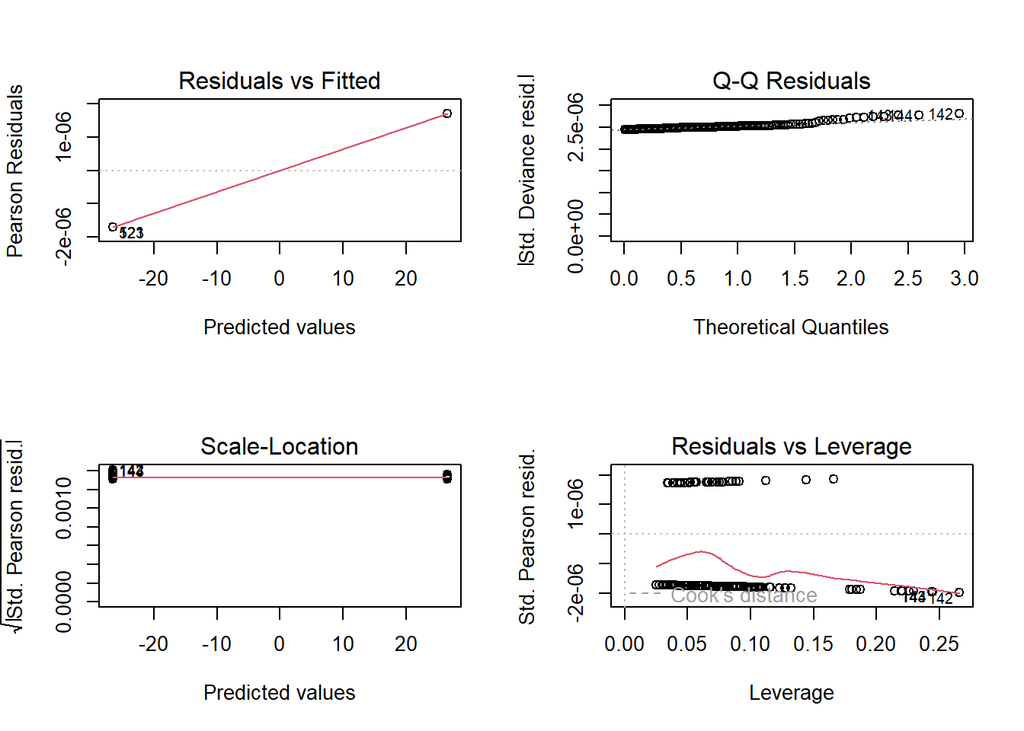

```r
# Assumptions Checking (Diagnostic Plots)
par(mfrow = c(2, 2))  # Set up a 2x2 plot layout
plot(binary_fish_model)
```

```r
# Predict probabilities for each observation
predicted_probabilities <- predict(binary_fish_model, type = "response", newdata = binary_fish_data)

# View the predicted probabilities
head(predicted_probabilities)
```

```
## 1 2 3 4 5 6
## 1 1 1 1 1 1
```

```r
# Set a threshold probability (e.g., 0.5)
threshold <- 0.5

# Convert predicted probabilities to binary predictions based on the threshold
predicted_classes <- ifelse(predicted_probabilities >= threshold, 1, 0)

# Calculate accuracy
accuracy <- mean(predicted_classes == binary_fish_data$IsBream)
print(paste("Accuracy:", accuracy))
```

```
## [1] "Accuracy: 1"
```

```r
# Create a data frame with actual and predicted values
prediction_df <- data.frame(
  Actual = binary_fish_data$IsBream,
  Predicted_Probability = predicted_probabilities)

# Sort the data frame by predicted probabilities for better visualization
prediction_df <- prediction_df[order(prediction_df$Predicted_Probability), ]

# Create a sequence of observation numbers
observation_numbers <- seq_along(predicted_probabilities)

# Plot predicted probabilities
plot(observation_numbers, predicted_probabilities, type = "l", col = "blue",
     xlab = "Observation", ylab = "Probability",
     main = "Predicted Probabilities vs. Actual Outcomes")

# Add actual outcomes as points (red for Bream, green for Non-Bream)
points(observation_numbers[binary_fish_data$IsBream == 1],
       rep(1, sum(binary_fish_data$IsBream == 1)), col = "red", pch = 19)
points(observation_numbers[binary_fish_data$IsBream == 0],
       rep(0, sum(binary_fish_data$IsBream == 0)), col = "green", pch = 19)

# Add legend
legend("topright", legend = c("Predicted", "Actual (Bream)", "Actual (Non-Bream)"),
       col = c("blue", "red", "green"), lty = 1, pch = c(NA, 19, 19), cex = 0.8)

# Predicted probabilities from the logistic regression model
predicted_probabilities <- predict(binary_fish_model, type = "response")

# Convert predicted probabilities to binary predictions (1 for Bream, 0 for Non-Bream)
predicted_classes <- ifelse(predicted_probabilities >= 0.5, 1, 0)

# Calculate accuracy
accuracy <- mean(predicted_classes == binary_fish_data$IsBream)
cat("Model Accuracy:", accuracy, "\n")
```

```
## Model Accuracy: 1
```

```r
# Predict classes using the logistic regression model
predicted_classes <- ifelse(predict(binary_fish_model, newdata = binary_fish_data, type = "response") > 0.5, "Bream", "Not Bream")

# Create a confusion matrix
confusion_matrix <- table(predicted_classes, as.factor(binary_fish_data$IsBream))

# Print confusion matrix
print(confusion_matrix)
```

```
##
## predicted_classes   0   1
##         Bream       0  35
##         Not Bream 123   0
```

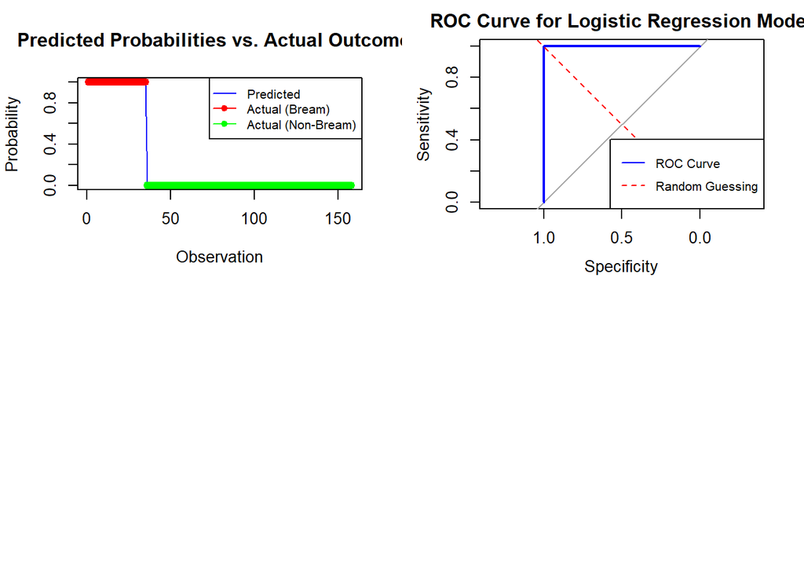

```r
# Calculate ROC curve
roc_curve <- roc(binary_fish_data$IsBream, predicted_probabilities)
# Plot ROC curve
plot(roc_curve, main = "ROC Curve for Logistic Regression Model",
     col = "blue", lwd = 2)

# Add diagonal line for reference
abline(a = 0, b = 1, col = "red", lty = 2)

# Add legend
legend("bottomright", legend = c("ROC Curve", "Random Guessing"),
       col = c("blue", "red"), lty = 1:2, cex = 0.8)
```

The standard errors for the coefficients are also very large, indicating high uncertainty in the parameter estimates.

The Z-values for all coefficients are 0, suggesting that none of the coefficients are significantly different from zero, which is unusual.

The null deviance is 167.108, indicating the deviance for the null model (model with no predictors).

The residual deviance is extremely close to zero (9.1665e-10), suggesting that the model perfectly fits the data. However, such a small residual deviance is highly suspicious and may indicate a problem with the model or data.

3. LDA

```r
library(MASS)
library(ggplot2)
library(memisc)
library(ROCR)
fish_independent <- as.matrix(fish_data[,c(2:7)])
fish_raw <- cbind(fish_independent, as.numeric(as.factor(fish_data$Species))-1)
colnames(fish_raw)[7] <- "Species"

smp_size_raw <- floor(0.75 * nrow(fish_raw))
train_ind_raw <- sample(nrow(fish_raw), size = smp_size_raw)
train_raw.df <- as.data.frame(fish_raw[train_ind_raw, ])
test_raw.df <- as.data.frame(fish_raw[-train_ind_raw, ])

fish_raw.lda <- lda(formula = train_raw.df$Species ~ ., data = train_raw.df)
fish_raw.lda
```

```
## Call:
## lda(train_raw.df$Species ~ ., data = train_raw.df)
##
## Prior probabilities of groups:
##          0          1          2          3          4          5          6
## 0.23728814 0.06779661 0.33050847 0.11016949 0.11864407 0.10169492 0.03389831
##
## Group means:
##      Weight  Length1  Length2  Length3    Height    Width
## 0 606.75000 30.04286 32.82500 38.07857 15.087593 5.368561
## 1 139.12500 18.06250 19.63750 22.01250  8.683462 3.107188
## 2 410.70256 26.25385 28.43846 30.14359  8.052692 4.863379
## 3 697.92308 42.07692 45.05385 48.33077  7.686423 5.088962
## 4 160.07143 20.47857 22.16429 24.87143  6.705193 3.668064
## 5  11.36667 11.38333 12.05833 13.18333  2.230200 1.370392
## 6 661.50000 31.27500 33.85000 36.97500 10.909300 6.085550
##
## Coefficients of linear discriminants:
##                   LD1          LD2          LD3           LD4          LD5
## Weight   0.0009369902 -0.004393679  0.005920675  0.0005264062 -0.007454277
## Length1  0.5336912432 -0.667421059  2.627508593  0.2663463685  0.603341261
## Length2  2.2569797013 -0.787185892 -3.939253042  1.7358433052 -0.281762929
## Length3 -2.5835854872  1.902224680  1.294967361 -1.7571935559 -0.141887995
## Height  -1.0403883006 -0.815285132 -0.376641738  0.9126095923  0.205558304
## Width    1.4365721608 -0.784684113 -0.548840893 -2.4073820742  0.034489472
##                  LD6
## Weight  -0.001472051
## Length1  3.871178621
## Length2 -3.579646965
## Length3 -0.071799457
## Height   0.240262393
## Width    0.418461615
##
## Proportion of trace:
##    LD1    LD2    LD3    LD4    LD5    LD6
## 0.7530 0.1862 0.0470 0.0115 0.0022 0.0001
```

```r
summary(fish_raw.lda)
```

```
##         Length Class  Mode
## prior    7     -none- numeric
## counts   7     -none- numeric
## means   42     -none- numeric
## scaling 36     -none- numeric
## lev      7     -none- character
## svd      6     -none- numeric
## N        1     -none- numeric
## call     3     -none- call
## terms    3     terms  call
## xlevels  0     -none- list
```

```r
print(fish_raw.lda)
```

```
## Call:
## lda(train_raw.df$Species ~ ., data = train_raw.df)
##
## Prior probabilities of groups:
##          0          1          2          3          4          5          6
## 0.23728814 0.06779661 0.33050847 0.11016949 0.11864407 0.10169492 0.03389831
##
## Group means:
##      Weight  Length1  Length2  Length3    Height    Width
## 0 606.75000 30.04286 32.82500 38.07857 15.087593 5.368561
## 1 139.12500 18.06250 19.63750 22.01250  8.683462 3.107188
## 2 410.70256 26.25385 28.43846 30.14359  8.052692 4.863379
## 3 697.92308 42.07692 45.05385 48.33077  7.686423 5.088962
## 4 160.07143 20.47857 22.16429 24.87143  6.705193 3.668064
## 5  11.36667 11.38333 12.05833 13.18333  2.230200 1.370392
## 6 661.50000 31.27500 33.85000 36.97500 10.909300 6.085550
##
## Coefficients of linear discriminants:
##                   LD1          LD2          LD3           LD4          LD5
## Weight   0.0009369902 -0.004393679  0.005920675  0.0005264062 -0.007454277
## Length1  0.5336912432 -0.667421059  2.627508593  0.2663463685  0.603341261
## Length2  2.2569797013 -0.787185892 -3.939253042  1.7358433052 -0.281762929
## Length3 -2.5835854872  1.902224680  1.294967361 -1.7571935559 -0.141887995
## Height  -1.0403883006 -0.815285132 -0.376641738  0.9126095923  0.205558304
## Width    1.4365721608 -0.784684113 -0.548840893 -2.4073820742  0.034489472
##                  LD6
## Weight  -0.001472051
## Length1  3.871178621
## Length2 -3.579646965
## Length3 -0.071799457
## Height   0.240262393
## Width    0.418461615
##
## Proportion of trace:
##    LD1    LD2    LD3    LD4    LD5    LD6
## 0.7530 0.1862 0.0470 0.0115 0.0022 0.0001
```

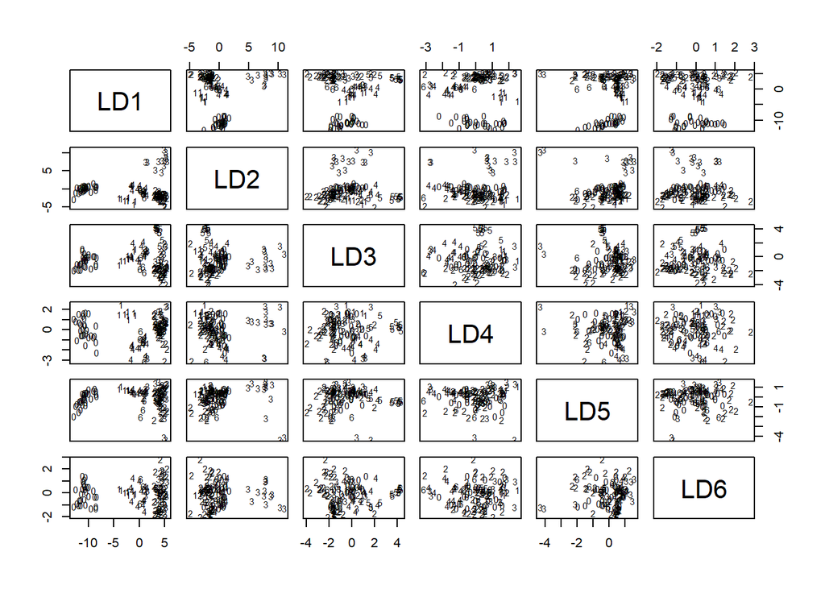

```r
plot(fish_raw.lda)
```

```r
fish_raw.lda.predict <- predict(fish_raw.lda, newdata = test_raw.df)
fish_raw.lda.predict$class
```

```
##  [1] 0 0 0 0 0 0 0 4 4 4 4 4 4 4 1 1 1 5 2 2 2 2 2 2 2 2 2 2 2 2 2 2 2 2 3 3 3 3
## [39] 5 5
## Levels: 0 1 2 3 4 5 6
```

```r
fish_raw.lda.predict$x
```

```
##            LD1         LD2         LD3         LD4         LD5          LD6
## 1   -9.5979893  0.80787017 -0.91083600 -0.66299319  0.11799186 -1.465891849
## 2   -9.9005238  2.25715552 -0.35795269 -0.64469440  1.61886088  0.863795179
## 3  -10.3099837 -0.65006454 -0.06361307 -0.18794736 -0.03440655  0.679792010
## 4  -10.0898437  0.25048438  1.02041092  0.11606148 -0.74322383  0.483084852
## 5   -8.6839565  0.40521454  0.75215498 -1.00276600 -0.27035946  1.153009575
## 6  -11.8383305 -0.47371838 -1.50229612  1.25368771 -1.29227529 -0.947438831
## 7   -9.5030858 -1.69513542 -2.85528862  2.58307254 -1.07581074 -0.487590745
## 8    0.3713592  0.50690551  1.43516806 -1.48232045  0.52977928 -0.176540729
## 9    0.8619311  0.26420653  1.35133409 -0.40278121  0.82949988  0.642551329
## 10   1.7724701 -0.14084134  1.52829530 -1.64601638  0.72629721  1.162958086
## 11  -0.6168459  0.58338411  2.22930190 -2.66372503  0.71049152  1.642782889
## 12   1.1648313  0.85083081  1.01812307 -1.00729147  1.05812193  1.147519486
## 13   0.1325545  0.02456673 -1.23922781 -0.61862254  0.32604916 -1.452324235
## 14   0.2235228  0.62948385 -1.03010276 -0.88847373  0.35343037 -1.405723128
```

[output cut: 26 more lines]

```r
#Filter the dataset for the two classes you want to predict
class_1 <- "Bream"  # class 1
class_2 <- "Pike"   # class 2

filtered_data <- fish_data[fish_data$Species %in% c(class_1, class_2), ]
str(filtered_data)
```

```
## 'data.frame':    52 obs. of  7 variables:
##  $ Species: chr  "Bream" "Bream" "Bream" "Bream" ...
##  $ Weight : num  242 290 340 363 430 450 500 390 450 500 ...
##  $ Length1: num  23.2 24 23.9 26.3 26.5 26.8 26.8 27.6 27.6 28.5 ...
##  $ Length2: num  25.4 26.3 26.5 29 29 29.7 29.7 30 30 30.7 ...
##  $ Length3: num  30 31.2 31.1 33.5 34 34.7 34.5 35 35.1 36.2 ...
##  $ Height : num  11.5 12.5 12.4 12.7 12.4 ...
##  $ Width  : num  4.02 4.31 4.7 4.46 5.13 ...
```

```r
fish_independent_new <- as.matrix(filtered_data[,c(2:7)])
fish_raw_new <- cbind(fish_independent_new, as.numeric(as.factor(filtered_data$Species))-1)
colnames(fish_raw_new)[7] <- "Species"

smp_size_raw_new <- floor(0.75 * nrow(fish_raw_new))
train_ind_raw_new <- sample(nrow(fish_raw_new), size = smp_size_raw_new)
train_raw.df_new <- as.data.frame(fish_raw_new[train_ind_raw_new, ])
test_raw.df_new <- as.data.frame(fish_raw_new[-train_ind_raw_new, ])

fish_raw.lda_new <- lda(formula = train_raw.df_new$Species ~ ., data = train_raw.df_new)
fish_raw.lda_new
```

```
## Call:
## lda(train_raw.df_new$Species ~ ., data = train_raw.df_new)
##
## Prior probabilities of groups:
##         0         1
## 0.7179487 0.2820513
##
## Group means:
##     Weight  Length1  Length2  Length3    Height    Width
## 0 640.3571 30.72143 33.54286 38.82500 15.402168 5.491629
## 1 709.3636 42.11818 45.09091 48.28182  7.805827 5.067845
##
## Coefficients of linear discriminants:
##                   LD1
## Weight  -0.0001221028
## Length1  0.5870949961
## Length2  2.1747021181
## Length3 -2.5101608046
## Height  -0.8829214979
## Width    1.3476254782
```

```r
summary(fish_raw.lda_new)
```

```
##         Length Class  Mode
## prior    2     -none- numeric
## counts   2     -none- numeric
## means   12     -none- numeric
## scaling  6     -none- numeric
## lev      2     -none- character
## svd      1     -none- numeric
## N        1     -none- numeric
## call     3     -none- call
## terms    3     terms  call
## xlevels  0     -none- list
```

```r
print(fish_raw.lda_new)
```

```
## Call:
## lda(train_raw.df_new$Species ~ ., data = train_raw.df_new)
##
## Prior probabilities of groups:
##         0         1
## 0.7179487 0.2820513
##
## Group means:
##     Weight  Length1  Length2  Length3    Height    Width
## 0 640.3571 30.72143 33.54286 38.82500 15.402168 5.491629
## 1 709.3636 42.11818 45.09091 48.28182  7.805827 5.067845
##
## Coefficients of linear discriminants:
##                   LD1
## Weight  -0.0001221028
## Length1  0.5870949961
## Length2  2.1747021181
## Length3 -2.5101608046
## Height  -0.8829214979
## Width    1.3476254782
```

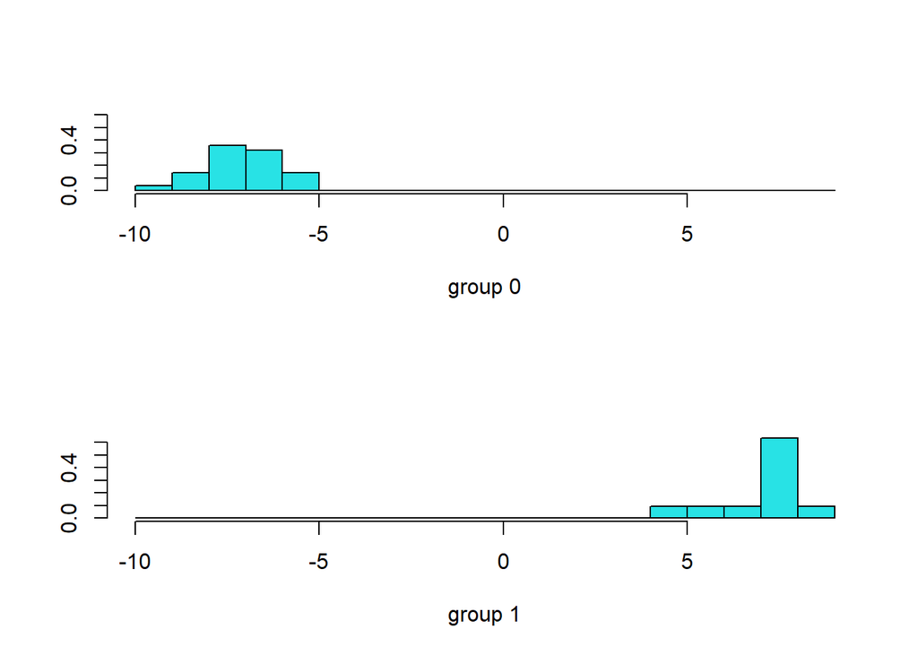

```r
plot(fish_raw.lda_new)
```

```r
fish_raw.lda.predict_new <- predict(fish_raw.lda_new, newdata = test_raw.df_new)
fish_raw.lda.predict_new$class
```

```
##  [1] 0 0 0 0 0 0 0 1 1 1 1 1 1
## Levels: 0 1
```

```r
fish_raw.lda.predict_new$x
```

```
##           LD1
## 1   -2.482224
## 4   -2.115083
## 7   -2.996832
## 12  -4.116108
## 20  -2.482781
## 26  -5.509143
## 28  -4.721243
## 129  6.941875
## 133 10.362987
## 137 11.171569
## 139 11.285216
## 140 11.546175
## 143 11.071574
```

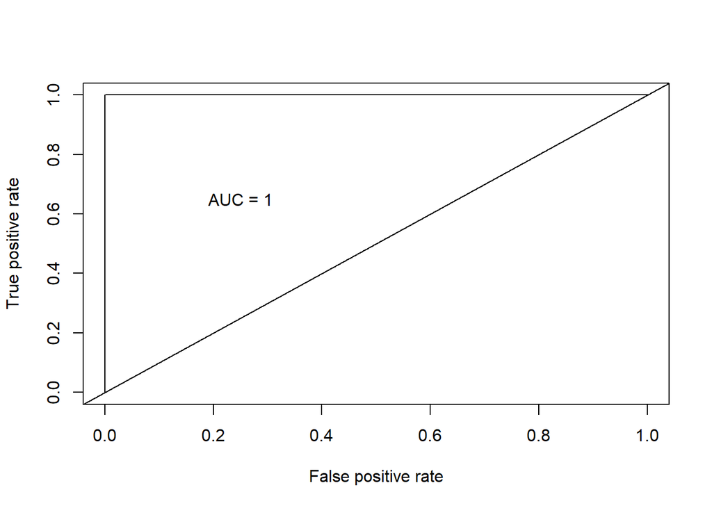

```r
# Get the posteriors as a dataframe.
fish_raw.lda.predict_new.posteriors <- as.data.frame(fish_raw.lda.predict_new$posterior)

pred <- prediction(fish_raw.lda.predict_new.posteriors[,2], test_raw.df_new$Species)
roc.perf = performance(pred, measure = "tpr", x.measure = "fpr")
auc.train <- performance(pred, measure = "auc")
auc.train <- auc.train@y.values
plot(roc.perf)
abline(a=0, b= 1)
text(x = .25, y = .65 ,paste("AUC = ", round(auc.train[[1]],3), sep = ""))
```

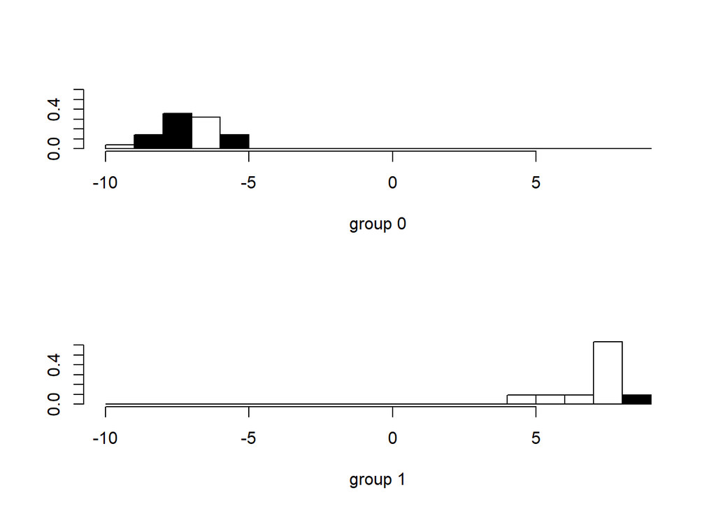

```r
# do a quick plot to understand how good the model is
plot(fish_raw.lda_new, col = as.integer(train_raw.df_new$Species))
```

```r
# Sometime bell curves are better
#plot(fish_raw.lda_new, dimen = 1, type = "b")
# THis plot shows the essense of LDA. It puts everything on a line and finds cutoffs.
# Partition plots
#partimat(Species ~ Weigth + Sepal.Width + Length1 + Length2 + Length3 + Height + Width, data=train_raw.df_new, method="lda")

#Trying with 3 species now
class_3 <- "Roach"
filtered_data_2 <- fish_data[fish_data$Species %in% c(class_1, class_2, class_3), ]

r2 <- lda(formula = Species ~ ., data = filtered_data_2, CV = TRUE)
r2
```

```
## $class
##  [1] Bream Bream Bream Bream Bream Bream Bream Bream Bream Bream Bream Bream
## [13] Bream Bream Bream Bream Bream Bream Bream Bream Bream Bream Bream Bream
## [25] Bream Bream Bream Bream Bream Bream Bream Bream Bream Bream Bream Roach
## [37] Roach Roach Roach Roach Roach Roach Roach Roach Roach Roach Roach Roach
## [49] Roach Roach Roach Roach Roach Roach Pike  Pike  Pike  Pike  Pike  Pike
## [61] Pike  Pike  Pike  Pike  Pike  Pike  Pike  Pike  Pike  Pike  Pike
## Levels: Bream Pike Roach
##
## $posterior
##            Bream         Pike        Roach
## 1   1.000000e+00 2.012119e-34 1.034783e-17
## 2   1.000000e+00 3.023242e-39 1.309972e-21
## 3   1.000000e+00 4.187242e-34 2.363360e-15
## 4   1.000000e+00 8.571696e-33 4.040802e-19
## 5   1.000000e+00 1.057995e-31 3.727808e-13
## 6   1.000000e+00 2.241225e-38 9.002227e-23
## 7   1.000000e+00 1.754800e-38 1.180891e-18
## 8   1.000000e+00 7.686246e-34 4.677437e-19
## 9   1.000000e+00 1.771285e-41 3.796832e-23
## 10  1.000000e+00 4.262150e-45 1.096383e-24
## 11  1.000000e+00 1.134951e-40 1.527319e-23
## 12  1.000000e+00 1.864686e-43 7.791601e-25
## 13  1.000000e+00 7.475450e-39 3.582872e-25
## 14  1.000000e+00 1.594487e-35 3.319364e-25
## 15  1.000000e+00 3.364127e-44 5.167962e-24
## 16  1.000000e+00 1.889614e-44 1.977444e-21
## 17  1.000000e+00 3.377824e-43 8.421908e-22
## 18  1.000000e+00 2.350792e-46 3.097307e-25
## 19  1.000000e+00 8.032351e-45 6.266719e-27
## 20  1.000000e+00 3.602933e-35 1.500904e-14
## 21  1.000000e+00 7.403420e-41 8.384097e-25
## 22  1.000000e+00 1.099417e-46 1.677517e-25
## 23  1.000000e+00 3.680007e-42 5.183707e-29
## 24  1.000000e+00 1.051560e-39 9.492887e-23
## 25  1.000000e+00 6.237664e-48 1.338342e-31
## 26  1.000000e+00 3.966749e-50 5.015657e-31
## 27  1.000000e+00 3.404188e-46 2.817395e-25
## 28  1.000000e+00 7.592836e-46 2.819333e-31
## 29  1.000000e+00 3.678071e-49 6.003500e-26
```

[output cut: 64 more lines]

[output not shown]

```r
head(r2$class)
```

```
## [1] Bream Bream Bream Bream Bream Bream
## Levels: Bream Pike Roach
```

```r
train <- sample(1:150, 75)
r3 <- lda(Species ~ ., # training model
           filtered_data_2,
           prior = c(1,1,1)/3,
           subset = train)
plda = predict(object = r3, # predictions
                newdata = filtered_data_2[-train, ])
head(plda$class)
```

```
## [1] Bream Bream Bream Bream Bream Bream
## Levels: Bream Pike Roach
```

```r
head(plda$posterior, 6) # posterior prob.
```

```
##    Bream         Pike        Roach
## 2      1 2.016314e-35 2.622180e-26
## 3      1 9.707160e-27 2.257671e-15
## 5      1 4.504300e-25 3.287334e-14
## 7      1 7.578040e-31 1.106266e-18
## 8      1 2.511723e-30 4.055529e-24
## 12     1 1.099448e-41 4.985175e-32
```

```r
head(plda$x, 3)
```

```
##         LD1        LD2
## 2 -7.079181 -0.9115685
## 3 -5.285633  0.3997888
## 5 -4.995881  0.3632627
```

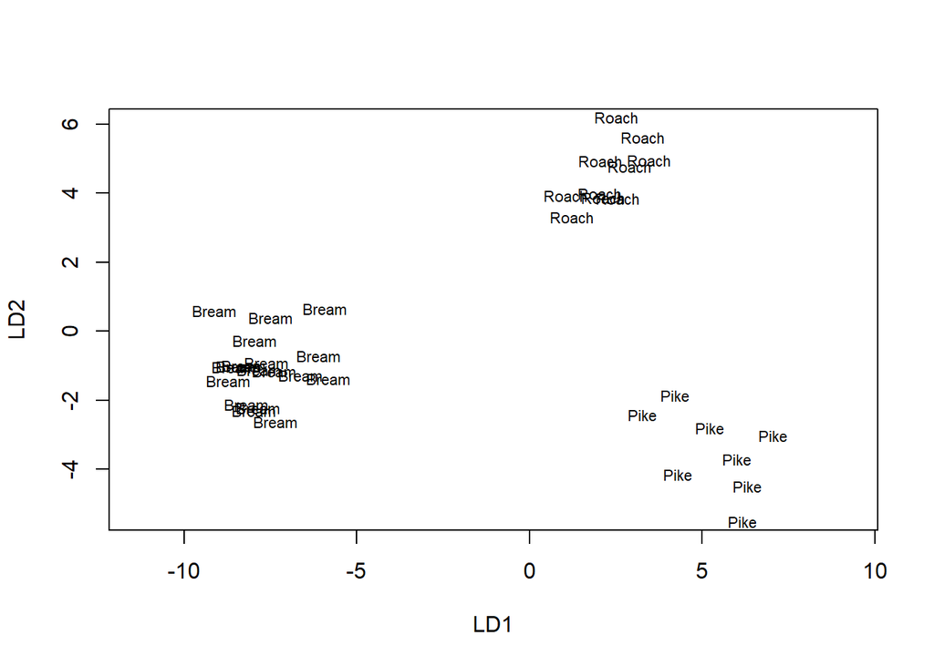

```r
plot(r3)
```

```r
head(r2$posterior, 3)
```

```
##   Bream         Pike        Roach
## 1     1 2.012119e-34 1.034783e-17
## 2     1 3.023242e-39 1.309972e-21
## 3     1 4.187242e-34 2.363360e-15
```

```r
train <- sample(1:150, 75)
r3 <- lda(Species ~ ., # training model
           filtered_data_2,
           prior = c(1,1,1)/3,
           subset = train)
plda = predict(object = r3, # predictions
                newdata = filtered_data_2[-train, ])
head(r2$posterior, 3)
```

```
##   Bream         Pike        Roach
## 1     1 2.012119e-34 1.034783e-17
## 2     1 3.023242e-39 1.309972e-21
## 3     1 4.187242e-34 2.363360e-15
```

```r
head(plda$posterior, 6) # posterior prob.
```

```
##    Bream         Pike        Roach
## 2      1 2.745600e-32 8.456646e-20
## 5      1 3.321194e-24 2.665772e-11
## 6      1 2.085600e-31 5.642055e-21
## 9      1 4.089494e-34 2.429608e-21
## 10     1 2.027515e-36 1.646657e-22
## 11     1 4.189328e-33 1.078628e-21
```

```r
head(plda$x, 3)
```

```
##         LD1        LD2
## 2 -6.243871 -1.5888041
## 5 -4.655221 -0.3866433
## 6 -6.128290 -2.1708734
```

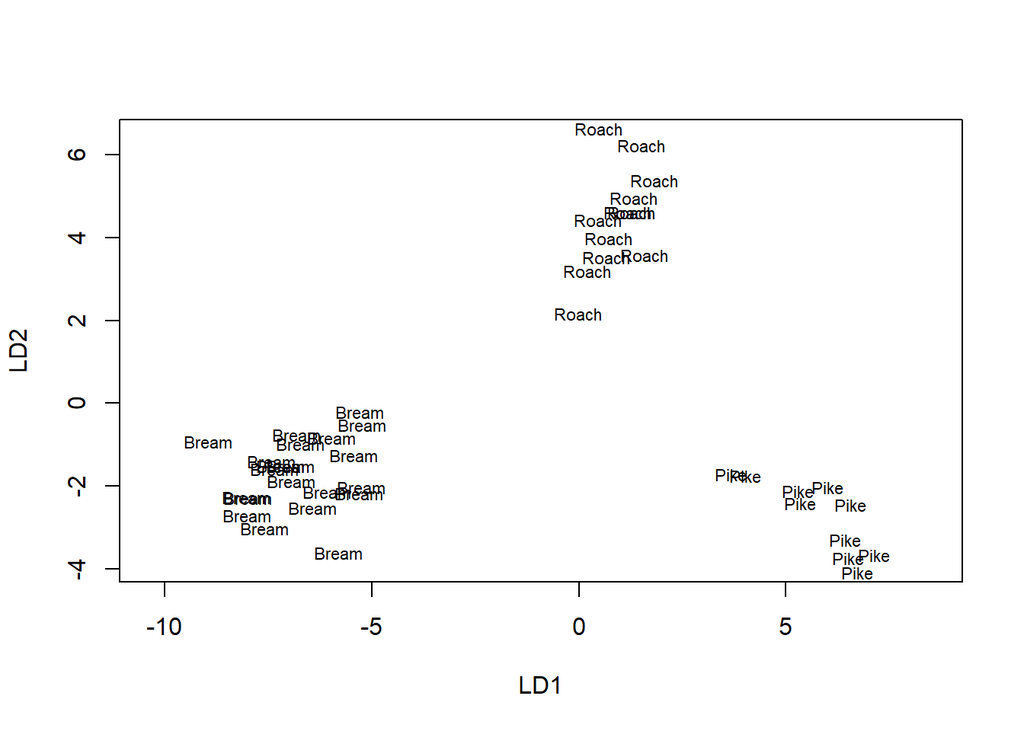

```r
plot(r3)
```

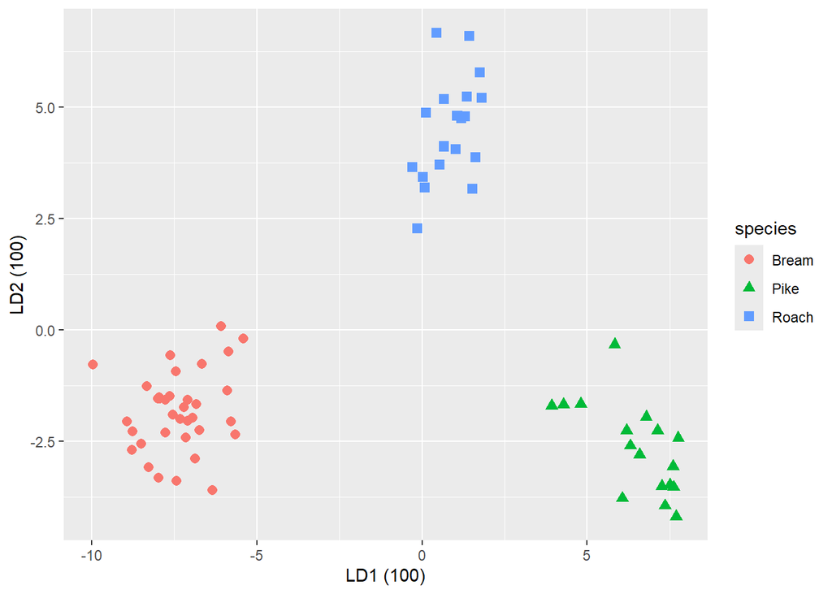

```r
r <- lda(Species ~ .,
          filtered_data_2,
          prior = c(1,1,1)/3)
prop.lda = r$svd^2/sum(r$svd^2)
plda <- predict(object = r,
               newdata = filtered_data_2)
dataset = data.frame(species = filtered_data_2[,"Species"],lda = plda$x)
ggplot(dataset) + geom_point(aes(lda.LD1, lda.LD2, colour = species, shape = species), size = 2.5) + labs(x = paste("LD1 (", percent(prop.lda[1]), ")", sep=""),y = paste("LD2 (", percent(prop.lda[2]), ")", sep=""))
```

```r
# Lets focus on accuracy. Table function
lda.train <- predict(fish_raw.lda_new)
train_raw.df_new$lda <- lda.train$class
table(train_raw.df_new$lda,train_raw.df_new$Species)
```

```
##
##      0  1
##   0 28  0
##   1  0 11
```

```r
# running accuracy on the training set shows how good the model is. It is not an indication of "true" accuracy. We will use the test set to approximate accuracy
lda.test <- predict(fish_raw.lda_new,test_raw.df_new)
test_raw.df_new$lda <- lda.test$class
table(test_raw.df_new$lda,test_raw.df_new$Species)
```

```
##
##     0 1
##   0 7 0
##   1 0 6
```

The mean values of the predictor variables for each group provide insight into the characteristics of Bream and Pike species. For example, Pike tend to have higher values for Length1, Length2, Length3, and lower values for Height and Width compared to Bream.

The model has reasonably good discriminative ability between the Bream and Pike species based on the given predictor variables (Weight, Length1, Length2, Length3, Height, and Width).

The AUC value indicates that the model performs well in distinguishing between Bream and Pike.

The imbalanced nature of the dataset could potentially affect the model’s performance, particularly in terms of sensitivity to the minority class (Pike). Techniques such as oversampling, undersampling, or using class weights may be necessary to address this imbalance.

The visualization of linear discriminants shows clear separation between the two groups, suggesting that the model can effectively classify new observations.

Overall, the LDA model seems to be performing well for the given classification task.

#Learning and Takeaways:

Variable Importance: The PCA analysis revealed that certain variables, such as “Weight” and “Length1”, contribute more significantly to the variation observed in the dataset compared to others. Understanding variable importance can help prioritize features for further analysis or model development.

Dimensionality Reduction: PCA effectively reduced the dimensionality of the dataset while retaining most of its variance. This dimensionality reduction simplifies subsequent analyses and models, making them computationally less expensive and potentially more interpretable.

Visualization of Data: Visualizing the data projected onto the principal components enabled the identification of patterns and clusters within the dataset. While some separation between species was observed, there were also areas of overlap, indicating potential challenges in classification.

Classification Performance: The subsequent LDA model provided insights into the discriminative ability of the original predictor variables in distinguishing between different species of fish. Evaluating classification accuracy, confusion matrices, and ROC curves helps assess the model’s performance and generalization ability.

Feature Interpretation: The coefficients of the linear discriminants in the LDA model shed light on how each original predictor variable contributes to the separation between fish species. Understanding these relationships can provide biological insights into the characteristics that differentiate species.

Model Validation: It’s crucial to validate the performance of models like LDA using appropriate metrics and techniques. This ensures that the model’s predictive capabilities generalize well to unseen data and are not overly influenced by noise or artifacts in the training dataset.

Interpretability vs. Performance Trade-off: Dimensionality reduction techniques like PCA offer interpretability by reducing the feature space to a smaller set of uncorrelated variables. However, there’s often a trade-off between interpretability and model performance. Balancing these factors is essential when choosing an appropriate analysis approach.

Overall, the analysis provided a comprehensive understanding of the fish dataset, including its underlying structure, patterns, and the discriminative power of its features. These insights can inform further research, model development, or decision-making processes related to fish species classification or other related tasks.